# The Little Learner.Friedman2023

This is the extended version of *flatten*<sup>2</sup> that works on tensors of arbitrary rank, but flattens only the innermost tensors<sup>2</sup>.

For example

<sup>28</sup>

Now, we descend into the tensors

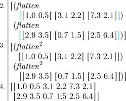

Correct.

The function *ext1* is useful for extending functions of one argument.

Now let's see how we extend functions of two arguments.

<sup>29</sup>

So now do we define a function *ext2*?

We do!

Before we do that, however, we need a couple of other comparision functions on ranks.

<sup>30</sup>

Sort of like

*of-rank?*

and more interesting?

Yes, indeed!

Sometimes we need to know if the rank of one tensor is higher than another. Here is a function *rank>* that is true if the rank of its first tensor argument is higher than the rank of its second tensor argument.

Here is its quick version

(**define** *rank>*

(λ (*t u*)

(*>* (*rank t*) (*rank u*))))

<sup>31</sup>

Could we write a recursive version of this as well?

We should!

(**define** *rank>*

(λ (*t u*)

(**cond**

((*scalar? t*) #f)

((*scalar? u*) #t)

(**else** (*rank> t|*<sub>0</sub> *u|*<sub>0</sub>)))))

Explain how this function works.

<sup>32</sup>

If *t* is a scalar, its rank is 0. Since 0 is not higher than any other rank, then the answer is

#f

On the other hand, if *u* is a scalar, and we already know that *t* is not a scalar, then the rank of *t* is higher than that of *u*, so the answer is

#t

And finally, if neither are scalars, we recursively compare the ranks of the 0th element of both *t* and *u*.

What else do we need?

Now define a function *of-ranks?* that takes arguments *n*, *t*, *m*, and *u*, where *n* is the rank we're checking for tensor *t*, and *m* is the rank we're checking for tensor *u*.

<sup>33</sup>

Here it is

(**define** *of-ranks?*

(λ (*n t m u*)

(**cond**

((*of-rank? n t*) (*of-rank? m u*))

(**else** **#**f))))

That was fun!

Great.

Here is an example

1. 1. (of-ranks?
2. 3 [[[8] [9]] [[2] [1]]] 2 [5])
3. 2. (of-rank? 2 [5])
4. 3. #f

Explain this same-as chart.

<sup>34</sup>

Since

(*of-rank?* 3 [[[8] [9]] [[2] [1]]])

is #t, the base test of the **cond** clause succeeds, so we must check if

(*rank* [5]) is 2

which it isn't. Hence we return #f.

Very good.

Now, we're ready to define *ext2*.

It is similar in its basic structure to *ext1*, but because the base function that is being extended has two arguments instead of one, we need *two* base ranks

(**define** *ext2* •

(λ (*f n m*)

(λ (*t u*)

(**cond**

((*of-ranks? n t m u*) (*f t u*))

(**else**

(*desc* (*ext2 f n m*) *n t m u*))))))

We make use of two support functions

*of-ranks?*

and

*desc*

Since we have two base ranks and two tensor arguments, deciding when we must descend and when we must not requires a little more thought.

<sup>35</sup>

We know that

*of-ranks?*

checks whether

*t* has rank *n*

*and*

*u* has rank *m*

This means that in the first clause of the **cond** expression, we check if *t* and *u* have reached their base ranks. If they have, we invoke the base function *f* on them.

Otherwise, it is time to descend into the tensors, and we use *desc* to do that. The first argument to *desc* is very similar to the first argument to *tmap* in *ext1* when it is used to descend into the tensor.

So, *desc* is invoked with

(*ext2 f n m*)

which is similar to

(*ext1 f n*)

which is in the definition of *ext1*.

Correct.

The recursive invocation of *ext2* produces a function that either invokes *f* on the two argument tensors if they each have their respective base rank, or descends into one or both of the tensors. This is the first argument to *desc*.

<sup>36</sup>

How do we decide which tensor, or tensors, we should descend into?

An excellent question.

To see that, let's look at *desc*

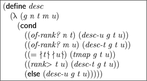

Here, *g* is the extended function

(*ext2 f n m*)

because of the way

*desc*

is invoked from within

*ext2*

The first couple of clauses address what happens when one of the two tensor arguments has reached its base rank. For example, if we have reached the base rank for *u*, then we need to descend only into *t*, and vice versa.

Define *desc-t*, which descends into *t*, and *desc-u*, which descends into *u*.

<sup>37</sup>

For *desc-t*, since we are descending into only one tensor, we use *tmap* to invoke *g* over each element of *t* (named *et*) and *u*

(**define** *desc-t*

(λ (*g t u*)

(*tmap* (λ (*et*) (*g et u*)) *t*)))

For *desc-u*, we similarly use *tmap* to invoke *g* on *t* and each element of *u* (named *eu*)

(**define** *desc-u*

(λ (*g t u*)

(*tmap* (λ (*eu*) (*g t eu*)) *u*)))

Excellent.

<sup>38</sup>

What happens if none of these clauses are relevant?

If the rank of *t* is higher than the rank of *u*, then we use *desc-t*, otherwise, we use *desc-u*.

<sup>39</sup>

And we decide this by using

*rank>*

from frame 32!

Could we see an example of how *ext2* is used?

Sure.

Let +<sup>0</sup><sup>,</sup><sup>0</sup> be a function that adds two scalars.

Define an extended version + of this base function.

<sup>40</sup>

We must invoke *ext2*, since the base function is a function of two arguments. The base rank for both arguments is 0

(**define** + •

(*ext2* +<sup>0,0</sup> 0 0))

How about another example?

Let *<sup>0</sup><sup>,</sup><sup>0</sup> be a function that multiplies two scalars.

Define an extended version * of this base function.

<sup>41</sup>

As before, we must invoke *ext2*, since the base function is a function of two arguments. The base rank for both arguments here is also 0

(**define** * •

(*ext2* *<sup>0,0</sup> 0 0))

Now, *any* function that uses * gets automatically extended. For example, define a function *sqr* that squares its tensor argument *t*.

<sup>42</sup>

Here it is

(**define** *sqr* •

(λ (*t*)

(* *t t*)))

We also have everything we need for defining *•* from frame 106:26.

Define •.

<sup>43</sup>

We can do this by extending •<sup>1</sup><sup>,</sup><sup>1</sup> with base ranks of 1 and 1

(**define** • •

(*ext2* •<sup>1,1</sup> 1 1))

Excellent.

We can use *ext2* in other ways. For example, we can define a function *<sup>2</sup><sup>,</sup><sup>1</sup>

(**define** *<sup>2,1</sup> •

(*ext2* * 2 1))

Explain what this function does.

<sup>44</sup>

Here the base function is

*'s definition relies on *0,0

Why does it need to be extended?

We're using different base ranks. This means that *<sup>2</sup><sup>,</sup><sup>1</sup> descends into both its arguments until it has reached a tensor<sup>2</sup> in its first argument, and a tensor<sup>1</sup> in its second argument, and then invokes * only on them. Let's see an example.

Let the tensor<sup>2</sup> *p* be

[[3 4 5]

[7 8 9]]

and the tensor<sup>1</sup> *t* be

[2 4 3]

Now complete this same-as chart, keeping in mind that we are first using *, each of whose arguments is at base rank 0

1. 1. (* *p t*)
2. 2. (* [[3 4 5] [7 8 9]] [2 4 3])

<sup>45</sup>

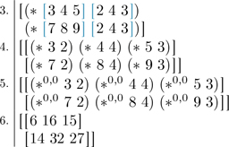

Indeed.

Here's a same-as chart showing how *<sup>2,1</sup> behaves on these same two arguments. Because *p* is at base rank 2 and *t* is at base rank 1, *<sup>2,1</sup> invokes * on them

1. 1. (*<sup>2</sup><sup>,</sup><sup>1</sup> *p t*)
2. 2. (* *p t*)

What happens next?

<sup>46</sup>

It produces the same result that we see in frame 45.

Correct.

Now let's look at a different pair of tensors, and see how * behaves with them.

Let *q* be a tensor<sup>2</sup>

[[8 1] [7 3] [5 4]]

and let *r* be another tensor<sup>2</sup>

[[6 2] [4 9] [3 8]]

Now complete this same-as chart

1. 1. (* *q r*)

<sup>47</sup>

Here, * immediately tackles the two tensors of the same length 3, so it descends into both simultaneously

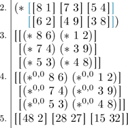

What happens with *<sup>2</sup><sup>,</sup><sup>1</sup>?

Let's find out!

Instead of descending into both tensors simultaneously, it recognizes that *q* is already at the base rank, and descends into *only r*

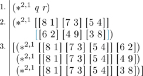

Now finish this same-as chart.

<sup>48</sup>

The invocations of *<sup>2</sup><sup>,</sup><sup>1</sup> are at their base ranks of 2 and 1, respectively, so we invoke * on the tensor arguments of *<sup>2</sup><sup>,</sup><sup>1</sup>

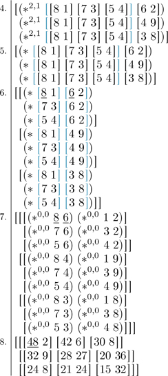

Is this different from the result for * in frame 47?

<sup>49</sup>

Indeed, so we can use the base ranks to change the behavior of extended functions.

Is there a use for that?

There is!†

But that's for a later chapter.

†This may be familiar to some as a precursor to matrix-vector multiplication.

<sup>50</sup>

Time for a break now.

## More Extendy Toys

*ext1* 183

*sqrt*<sup>0</sup> 183, *sqrt* 183

*zeroes*<sup>0</sup> 183, *zeroes* 183

*sum*<sup>1</sup> 184, *sum* 184

*flatten*<sup>2</sup> 184, *flatten* 184

*ext2* 187

+<sup>0,0</sup> 189, + 189

*<sup>0,0</sup> 189, * 189

*sqr* 189

*<sup>2,1</sup> 190

**How about some maple walnut chiffon pie?**

**Nutty and smooth at the same time!**

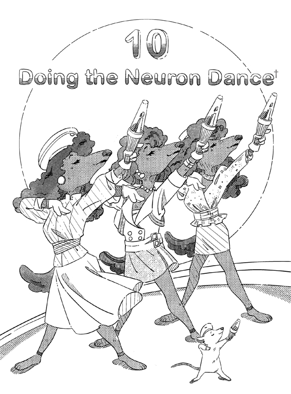

†With apologies and thanks, *The Pointer Sisters*: June (1953–2006), Ruth (1946–), and Anita (1948–); and also music arrangers Alta Sherral Willis (1947–2019) and Daniel Sembello (1963–2015).

Wasn't the maple walnut chiffon pie heavenly?

<sup>1</sup>

It was maybe the best slice of pie, ever!

Onwards, then!

So far, our target functions have been very limited.

<sup>2</sup>

How so?

Functions like *line*, *quad*, and *plane* use only a small number of parameters, and are suitable for only certain kinds of data sets that can be modeled by these simple functions.

<sup>3</sup>

Why is that a problem?

We cannot recognize irises.

<sup>4</sup>

*Irises?* What do irises have to do with anything?

We'll get to that.

If we have more complex target functions, we could teach them to recognize irises and other things using data sets that consist of appropriately labeled images.

Or, we could teach them to recognize objects, faces, and other interesting features in images. Or, understand speech, or written language, or do many other things that are otherwise difficult for machines to do.

<sup>5</sup>

How do we teach them?

We define these target functions to have a *θ* and then we use one of our gradient-descent functions to find the well-fitted *θ* that allows us to perform the task we are interested in.

<sup>6</sup>

How do we find these larger and more complex target functions?

Like all other functions, we construct them from simpler units.

<sup>7</sup>

Aha!

That sounds familiar. We always design functions by dividing larger functions up into smaller ones.

Is this similar?

In some ways, yes.

But these smaller functions must also be parameterized, because we still want to use gradient descent optimization to learn the parameters of all of these smaller functions working together.

<sup>8</sup>

That sounds exciting.

What do these simpler parameterized functions look like?

Let's find out.

Here is a function *rectify*<sup>0</sup>

(**define** *rectify*<sup>0</sup> •

(λ (*s*)

(**cond**

((*< s* 0.0) 0.0)

(**else** *s*))))

Explain what this function does.

<sup>9</sup>

The function *rectify*<sup>0</sup> expects a scalar argument and it results in 0.0 if its argument is negative. Otherwise it is like the identity function.

Correct.

Is *rectify*<sup>0</sup> a *linear* function?

<sup>10</sup>

*rectify*<sup>0</sup> relies on a **cond**-expression, and from frame 101:11, a linear function may use only addition and scaling, but **cond** is different from either of them.

Good.

The extended version of *rectify*<sup>0</sup> is named *rectify*

(**define** *rectify* •

(*ext1 rectify*<sup>0</sup> 0))

<sup>11</sup>

Oh, so it works on a tensor, invoking the same behavior on each of its scalars as is familiar from frames 49:11 and 183:23.

So, by extension, is *rectify* also nonlinear?

Yes, it is.

Nonlinear functions like *rectify* are referred to as *deciders*.† They make a small decision about their arguments and transfer the decision to their result.

†Otherwise known as *activation functions.* We use the term *deciders* here to emphasize their intent.

<sup>12</sup>

Is a decider one of the simpler functions we use?

Yes.

Using a decider as one of the smaller functions in our collection of functions allows us to make tiny decisions involving just a few parameters that assimilate into a final decision such as what kinds of irises we have.

<sup>13</sup>

But *rectify* has no parameters.

How can we use it to learn anything?

That is a great question!

We combine it with another simple function, but this one is parameterized.

Here's a familiar function. It is similar to *plane* from frame 105:25

(**define** *linear*<sup>1,1</sup> •

(λ (*t*)

(λ (*θ*)

(+ (*•* *θ*<sub>0</sub> *t*) *θ*<sub>1</sub>))))

<sup>14</sup>

Why does this function have a “1,1” superscript?

The “1,1” superscript reminds us that it expects both *θ*<sub>0</sub> and *t* to be tensors<sup>1</sup> and will take on the usual extended function behavior if either of the tensors are of higher rank. And, unlike *rectify*, this function *is* linear.

Explain why.

<sup>15</sup>

This function uses addition (+) and dot product (•) from frame 106:26, which itself uses only addition and scaling.†

This makes *linear*<sup>1</sup><sup>,</sup><sup>1</sup> a linear function and deserving of its name.

†To make a fine point of this, • in this definition uses one tensor from parameters and one from the argument, which makes the resulting scalar multiplications between a parameter and an argument. Hence we say that • uses scaling. We use addition when all those scalar products are summed. This makes • in this context a linear operation.

Excellent.

Now explain *linear*<sup>1</sup><sup>,</sup><sup>1</sup>.

<sup>16</sup>

The function *linear*<sup>1</sup><sup>,</sup><sup>1</sup> combines its tensor<sup>1</sup> argument *t* with the parameter *θ*<sub>0</sub>, which is also a tensor<sup>1</sup>, into a scalar. It then adds the resultant scalar to *θ*<sub>1</sub>.

Correct.

We compose the non-parameterized, nonlinear decider *rectify* with *linear*<sup>1</sup><sup>,</sup><sup>1</sup> to get this parameterized nonlinear function, *relu*<sup>1</sup><sup>,</sup><sup>1</sup>

(**define** *relu*<sup>1,1</sup> •

(λ (*t*)

(λ (*θ*)

(*rectify* ((*linear*<sup>1,1</sup> *t*) *θ*)))))

<sup>17</sup>

That's an odd name, *relu*<sup>1</sup><sup>,</sup><sup>1</sup>, isn't it?

The name *relu* is short for *rectifying linear unit*.

Again, the “1,1” superscript is a reminder that we're dealing with tensors<sup>1</sup> for both *t* and *θ*<sub>0</sub>.

<sup>18</sup>

Oh, because it combines *rectify* and *linear*<sup>1</sup><sup>,</sup><sup>1</sup>.

Now it becomes obvious, doesn't it?

Explain the function *relu*<sup>1</sup><sup>,</sup><sup>1</sup>.

<sup>19</sup>

It *rectifies* the scalar result of *linear*<sup>1</sup><sup>,</sup><sup>1</sup>.

That is right.

The function *relu*<sup>1</sup><sup>,</sup><sup>1</sup> makes a *weighted decision* about its argument tensor *t*.

<sup>20</sup>

What is a *weighted* decision?

Each element of the tensor *θ*<sub>0</sub> is known as a *weight*. Each weight decides how much the corresponding element in the argument matters in the final decision.

The closer a weight is to 0.0, the less that element in the argument matters.

<sup>21</sup>

So, this looks similar to *w* from frame 22:11.

What about *θ*<sub>1</sub>?

Good question.

It is known as a *bias*. It is similar to *b* also from frame 22:11.

The bias parameter shifts the point at which *rectify* makes its decision to result in 0.0.

<sup>22</sup>

How does *bias* do that?

If the bias is *positive*, it increases the result produced by *•*, raising the chances that the result will pass through *rectify* unchanged.

Similarly, if it is *negative*, it decreases the result produced by *•*, lowering the chances that the result will pass through *rectify* unchanged and therefore more likely to become 0.0.

<sup>23</sup>

Ah, so when that result is *rectify*'d, the bias determines whether the final result is 0.0.

Correct.

If the argument were a zeroed tensor, the bias alone would determine if *relu*<sup>1</sup><sup>,</sup><sup>1</sup> should result in a 0.0 or not.

<sup>24</sup>

Could we see an example of *relu*<sup>1</sup><sup>,</sup><sup>1</sup> in action?

Here is a same-as chart

with weights

*θ*<sub>0</sub> being [7.1 4.3 *−*6.4]

with bias

*θ*<sub>1</sub> being 0.6

and

with the argument tensor

*t* being [2.0 1.0 3.0]

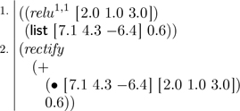

Complete this same-as chart.

<sup>25</sup>

Here goes

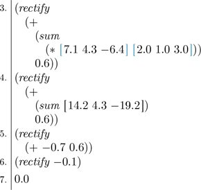

Perfect.

Now explain why we get 0.0?

<sup>26</sup>

We get 0.0 because the linear combination of *θ*<sub>0</sub>, *θ*<sub>1</sub>, and *t* gives us *−*0.1, which is less than 0.0.

This is why *rectify* does not pass it through, and instead produces 0.0.

Good.

Functions like *relu*<sup>1</sup><sup>,</sup><sup>1</sup> are known as *artificial neurons*. Each neuron has a linear part, like *linear*<sup>1</sup><sup>,</sup><sup>1</sup>, and a nonlinear decider like *rectify*.

<sup>27</sup>

*Neurons* sound like they come from biology.

## The Rule of Artificial Neurons

An artificial neuron is a parameterized linear function composed with a nonlinear decider function.

They do.

The function *relu*<sup>1</sup><sup>,</sup><sup>1</sup> is a simplified model of how real neurons in the brain work.

This is also why our compositionally constructed target functions are known as *neural networks*, or neural nets for short.†

†Thanks, Warren Sturgis McCulloch (1898–1968) and Walter Harry Pitts, Jr. (1923–1969).

<sup>28</sup>

The function *relu*<sup>1</sup><sup>,</sup><sup>1</sup> seems pretty simple.

Can it really help identify irises?

Great question.

With a sufficiently large number of these units, we can model very complex functions.

<sup>29</sup>

That seems very hard to believe.

It does indeed.

Let's see an illustration of how multiple uses of *relu*<sup>1</sup><sup>,</sup><sup>1</sup>s can be combined to do more interesting things.

<sup>30</sup>

Exciting!

We start by drawing the graph of *relu*<sup>1</sup><sup>,</sup><sup>1</sup> with *θ*<sub>0</sub> as [1.0] and *θ*<sub>1</sub> as *−*1.0.

For this graph, we assume that for any given *x*, we find the *y* by invoking

((*relu*<sup>1</sup><sup>,</sup><sup>1</sup> [*x*]) *θ*)

As an example, find the result of

*y* for *x* = 0.5

<sup>31</sup>

Here it is

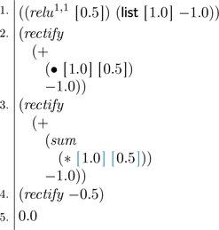

This gives us a point (0.5, 0.0) on the graph.

Correct.

Here is the graph

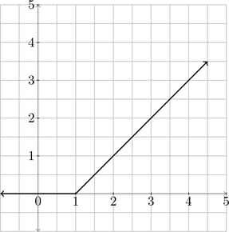

<sup>32</sup>

That looks like a line with slope 1.0 that is cut off below the *x*-axis.

Yes.

It has a sharp bend at the point it hits the *x*-axis.

Explain why this is so.

<sup>33</sup>

This is because *rectify* does not let any *y* less than 0.0 pass through.

Excellent.

Let's assume that *θ*<sub>0</sub> is a tensor<sup>1</sup> with exactly one element, and let's name that element *p*. In other words, *θ*<sub>0</sub> is

[*p*]

Similar to *line*, *p* determines the slope of the slanted portion of the graph, and *θ*<sub>1</sub> is where the line cuts the *y*-axis (or would cut it if *rectify* didn't stop it).

Find the point where the graph of *relu*<sup>1</sup><sup>,</sup><sup>1</sup> meets the *x*-axis and has a bend in it.

<sup>34</sup>

The equation of the line is

*y* = *px* + *θ*<sub>1</sub>

That's right.

When *θ*<sub>1</sub> is increased, *x* decreases

and

when *θ*<sub>1</sub> is decreased, *x* increases

<sup>35</sup>

Does this mean that the graph would shift to the right when *θ*<sub>1</sub> is decreased, and it would shift to the left when *θ*<sub>1</sub> is increased?

Here's what it looks like when *θ*<sub>1</sub> increases from *−*1.0 to +0.5

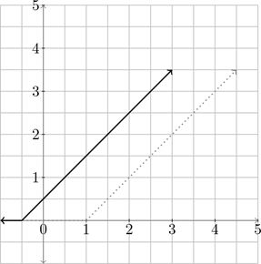

Here, the shifted graph (i.e., when *θ*<sub>1</sub> is +0.5) is solid. The graph has shifted to the left as we have increased *θ*<sub>1</sub>.

Draw the graph when we reduce *θ*<sub>1</sub> instead from *−*1.0 to *−*1.5.

<sup>36</sup>

The dark line now moves to the right while the dotted line stays the same

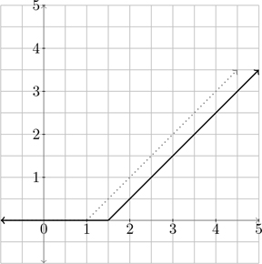

But, how does this allow us to build *interesting* functions?

Patience! It *is* a virtue, after all.

Explain this function *half-strip*

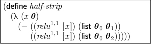

<sup>37</sup>

For a given *x*, this function determines *relu*<sup>1</sup><sup>,</sup><sup>1</sup> results, once for *θ*<sub>0</sub> and *θ*<sub>1</sub> and then once for *θ*<sub>0</sub> and *θ*<sub>2</sub>. Finally, it subtracts the second result from the first.

Yes, that is correct.

Let's look at the graph for a *half-strip* where *θ*<sub>0</sub> is as before (i.e., [1.0]) and

*θ*<sub>1</sub> is *−*1.0

Let's take

*θ*<sub>2</sub> to be *−*1.5

Here, the two *relu*<sup>1</sup><sup>,</sup><sup>1</sup>s are the same as in the graph in frame 36

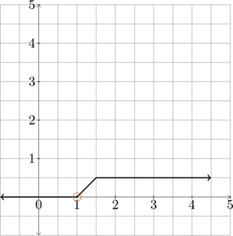

Why does this graph look this way?

<sup>38</sup>

For all *x* less than 1.0, both *relu*<sup>1</sup><sup>,</sup><sup>1</sup>s are 0.0, so the dark line lies on the *x*-axis. Between *x* = 1.0 and *x* = 1.5, the first *relu*<sup>1</sup><sup>,</sup><sup>1</sup> starts to become positive, but the second *relu*<sup>1</sup><sup>,</sup><sup>1</sup> is still 0.0.

This causes their difference to rise until *x* = 1.5, but then both *relu*<sup>1</sup><sup>,</sup><sup>1</sup>s start rising at the same rate, so the difference between them stays the same, at 0.5.

Why is it named as a *half-strip*? And, what is that orange circle at one end of it?

The space between the *x*-axis and the dark line looks like a *strip* that begins where the line meets the *x*-axis. We refer to this as the *left* end of the strip. We highlight ends with orange circles.

<sup>39</sup>

This strip seems to have only one end.

Indeed.

Since the strip has only one end (and not two), it is named a *half* -strip.

<sup>40</sup>

So can we get a function *full-strip* that has both ends of the strip?

Yes, we can, by subtracting two half-strips.

Here's another graph which shows two *half-strip*s with different values for *θ*<sub>1</sub> and *θ*<sub>2</sub>. Let's choose *θ*<sub>1</sub> to be *−*3.0 and *θ*<sub>2</sub> to be *−*3.5

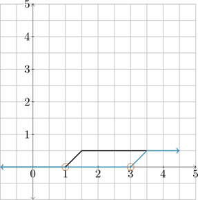

The dark half-strip here is the first half-strip in frame 38, and the turquoise one is the second half-strip.

<sup>41</sup>

Okay.

The second half-strip shifted to the right here because *p* in frame 34 is a positive number, lower values of *θ*<sub>1</sub>, −3.0, and *θ*<sub>2</sub>, −3.5, in the turqoise half-strip cause it to lie to the right of the dark half-strip that has values of −1 and −1.5.

Correct.

We now combine two half-strips to define a full strip

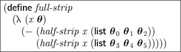

<sup>42</sup>

It seems as if we are subtracting the second half-strip from the first.

Could we see what the graph looks like?

Sure.

Let's take our parameters from the two half-strips in frame 41.

We invoke *full-strip* with *θ*<sub>0</sub> and *θ*<sub>3</sub> both being [1.0]. We let *θ*<sub>1</sub> be *−*1.0 and *θ*<sub>2</sub> be *−*1.5. And finally, we let *θ*<sub>4</sub> be *−*3.0 and *θ*<sub>5</sub> be *−*3.5.

Here's the graph for it

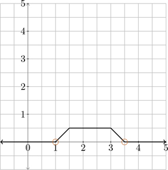

Why does this graph look this way?

<sup>43</sup>

Our two half-strips have a *y*-value of 0.0 for all *x*-values less than 1.0.

Between *x* = 1.0 and *x* = 1.5, the first half-strip rises to 0.5, but the second one is still 0.0. So the dark line, which represents the difference, rises to 0.5 as well and stays at 0.5 until *x* = 3.0.

At *x* = 3.0, the value of the second half-strip starts to rise towards 0.5 so the difference starts to fall until *x* = 3.5 at which point it becomes 0.0 again and stays that way for every remaining value of *x*.

Why do we have 6 different parameters for *full-strip*?

Good observation.

This allows us to have different slopes at the two ends of the strip, and it allows us to control how wide and tall we would like our strip to be.

<sup>44</sup>

Why is this named a *full-strip*?

This is a *full-strip* because the space between the dark line and the *x*-axis now has a left end (at *x* = 1.0) and also a right end (at *x* = 3.5) where the dark line meets the *x*-axis for a second time.

By appropriately manipulating *θ*<sub>0</sub>, *θ*<sub>3</sub>, *θ*<sub>1</sub>, *θ*<sub>4</sub>, *θ*<sub>2</sub>, and *θ*<sub>5</sub>, we get strips of any size and any slopes at the two ends.

<sup>45</sup>

What good are these full-strips and half-strips?

Full and half strips can be combined using addition and subtraction.

<sup>46</sup>

Adding the full and half strips together has given us a nonlinear function.

Could we see its graph?

Here is its graph

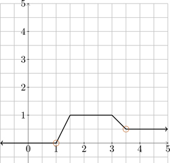

<sup>47</sup>

We have two orange circles here for the ends of the strips, and a more interesting graph.

Yes.

Just how interesting a function we can come up with is usually estimated by the number of parameters available for us to update and the number of invocations of *relu*<sup>1</sup><sup>,</sup><sup>1</sup> we rely on.

How many parameters and *relu*<sup>1</sup><sup>,</sup><sup>1</sup> invocations do we have here?

<sup>48</sup>

The function *half-strip* needs 3 parameters and has 2 *relu*<sup>1</sup><sup>,</sup><sup>1</sup> invocations.

The function *full-strip* needs 6 parameters and has 4 *relu*<sup>1</sup><sup>,</sup><sup>1</sup> invocations.

So, the function in frame 46 has 9 parameters and 6 *relu*<sup>1</sup><sup>,</sup><sup>1</sup> invocations.

Since *relu*<sup>1</sup><sup>,</sup><sup>1</sup> is an artificial neuron, this is an example of how to combine simple artificial neurons to get a more complex function.

<sup>49</sup>

How can we get even more interesting functions using neurons?

To get yet more interesting functions, we break them down into full and half strips† and combine them using addition and subtraction.

Here's a very interesting function broken up into strips (shown with dotted turquoise lines)

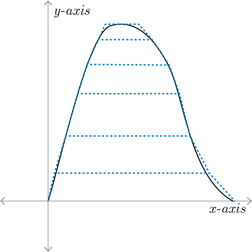

†Thanks, Henri Léon Lebesgue (1875–1941).

<sup>50</sup>

Can the strips in this graph be constructed using *full-strip* and then added together?

Yes, they can.

We say that these strips together *approximate* the original graph.

<sup>51</sup>

What does approximate here mean?

The edges of the strips are straight lines, but the graph of the function itself may not follow those straight lines exactly. For example, see the top strip in the graph in frame 50.

This means our strips get us close to the graph, but there are always going to be differences when the graph is curved.†

This is why we say that the strips approximate the function.‡

<sup>52</sup>

Okay.

†The strips give us what is known as a piecewise-linear approximation.

‡We can increase the number of strips by decreasing the height of each of the strips, and this allows us to get arbitrarily close to the actual curve of the function.

While ours has been merely a simple demonstration with only tensors<sup>1</sup> whose length is always 1, the general principles have been proven for a tensor<sup>1</sup> of any length, and for many different kinds of deciders. The results are known as the theorems of *universal approximation*.†

<sup>53</sup>

Wow. This way of constructing target functions with strips seems quite burdensome.

†Thanks, Halbert Lynn White Jr. (1950–2012), George Cybenko (1952–),

Maxwell Stinchcombe (1957–), and

Kurt Hornik (1963–).

The idea of using strips is to illustrate only that artificial neurons can be used as building blocks for very complex functions. We don't use it in practice.

<sup>54</sup>

How do we build neural networks in practice?

We build them in a more elegant fashion so that they are easier to design and build.

But that can wait until the next chapter.

<sup>55</sup>

Excellent.

What's for dessert?

## Neural Toys

*rectify* 197

*linear*<sup>1,1</sup> 197

*relu*<sup>1,1</sup> 198

**A *medovik* (медовик) is required.**

**All eleven layers of it!**

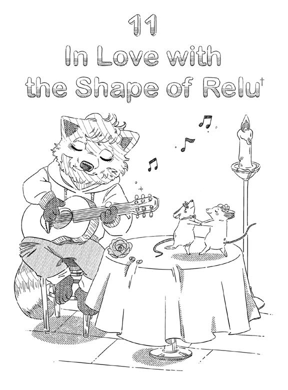

†With apologies and thanks to Ed Sheeran (1991–).

How was the *medovik*?†

†Thanks, 20th Century Cafe (2013–2021) and especially Michelle Polzine.

<sup>1</sup>

Gooey and yummy.

The *medovik* is appropriate because now we're going to learn about layers.

<sup>2</sup>

What kinds of layers?

Chapter 10 is about individual neurons.

Here, we put individual neurons together into *layers* in order to build bigger neural networks.

<sup>3</sup>

What are layers?

We can think of a layer as a group of neurons (like *relu*<sup>1</sup><sup>,</sup><sup>1</sup>) that all operate on the same tensor.

More technically, a layer is made up of a *layer function* and a *θ* that contains parameters for the layer function.

<sup>4</sup>

What is a layer function?

A layer function is a function of the form

(λ (*t*)

(λ (*θ*)

*… tensor producing body …*))

<sup>5</sup>

That looks like a target function.

It is, and all layer functions can be target functions.

The tensor argument *t* to the layer function is known as the *input* to the layer.

<sup>6</sup>

The layer function also needs a *θ* before it can produce a tensor.

Correct.

We provide the *layer function* with an input *and* a *θ*, and the results of each of its neurons are gathered into a tensor, which is the result produced by the layer function.

<sup>7</sup>

Is this result the *output* of the layer?

But of course!

<sup>8</sup>

It's time for an example, isn't it?

It definitely is.

Let's begin with an example of a

layer

that has, say,

4 neurons

As we have just stated above, this layer takes in a tensor and results in a tensor. For now, let's imagine that it takes a tensor<sup>1</sup> *t* of length 7.

<sup>9</sup>

The only kind of neuron we know of right now is

*relu*<sup>1</sup><sup>,</sup><sup>1</sup>

That is correct.

This layer function then invokes each of those 4 *relu*<sup>1</sup><sup>,</sup><sup>1</sup>s on *t*, this length 7 tensor<sup>1</sup>.

<sup>10</sup>

Won't it also need to send some weights (from frame 199:21) and biases (from frame 199:22) in a *θ* for these invocations?

A very good observation.

Let's suppose that we have 4 weights, which are tensors<sup>1</sup>

*w|*<sub>0</sub>, *w|*<sub>1</sub>, *w|*<sub>2</sub>, and *w|*<sub>3</sub>

<sup>11</sup>

And what about the biases?

Let's refer to the biases for each of those 4 *relu*<sup>1</sup><sup>,</sup><sup>1</sup>s as

*b|*<sub>0</sub>, *b|*<sub>1</sub>, *b|*<sub>2</sub>, and *b|*<sub>3</sub>

<sup>12</sup>

Okay.

What is the shape of each of these weights?

*w|*<sub>0</sub>, *w|*<sub>1</sub>, *w|*<sub>2</sub>, and *w|*<sub>3</sub>

<sup>13</sup>

Since we're sending them to *relu*<sup>1</sup><sup>,</sup><sup>1</sup>, they should each have the same shape as *t*, which is

(**list** 7)

With that information, what can we say about the shape of *w*?

<sup>14</sup>

We can say that *w* has the shape

(**list** 4 7)!

And how about the shape of *b*?

<sup>15</sup>

Since the biases to any *relu*<sup>1</sup><sup>,</sup><sup>1</sup> must be a scalar, *b* is a tensor of shape

(**list** 4)

Excellent.

Now *w* and *b* become the first two members of the *θ* with which we'll invoke the *relu*<sup>1</sup><sup>,</sup><sup>1</sup>s.

What do each of those 4 *relu*<sup>1</sup><sup>,</sup><sup>1</sup>s produce?

<sup>16</sup>

They produce 4 scalars.

Should we put these 4 scalars into a tensor<sup>1</sup>?

Very perceptive.

Here's a way to write this layer function

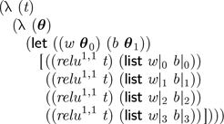

Here we invoke *relu*<sup>1</sup><sup>,</sup><sup>1</sup> 4 times, with *t* as the input tensor and we build 4 separate *θ*s from the elements of *w* and *b*.

<sup>17</sup>

That seems a little clumsy.

It is, and we'll clean it up shortly.

What is important is that each *relu*<sup>1</sup><sup>,</sup><sup>1</sup> produces a scalar, which means that the result of this layer is a tensor<sup>1</sup> of shape

(**list** 4)

<sup>18</sup>

So this layer function accepts an input *t* of shape

(**list** 7)

and a *θ*

with weights of shape

(**list** 4 7)

and biases of shape

(**list** 4)

to produce a result of shape

(**list** 4)

Can we generalize this?

Indeed, we can.

Layers with this structure are known as *dense* layers.†

†Also known as *fully-connected* layers.

<sup>19</sup>

There seems to be a special relationship between the shapes of the tensors in this layer.

There is!

In general, the layer function of a dense layer with *m* neurons takes one argument *t* which is a tensor<sup>1</sup> of shape

(**list** *n*)

It then accepts a suitable *θ*

with weights of shape

(**list** *m n*)

and biases of shape

(**list** *m*)

and invokes each of those *m* neurons on *t*, to produce

*m*

scalars, which form a tensor<sup>1</sup>.

We say that the *width* of this layer is *m*.

<sup>20</sup>

In our example, *m* is 4 and *n* is 7.

Since a dense layer of width *m* produces a tensor of the shape

(**list** *m*)

in our example, the tensor will have the shape

(**list** 4)

There ought to be a law for this!

## The Law of Dense Layers

(Initial Version)

A dense layer function invokes *m* neurons on an *n* element input tensor<sup>1</sup> and produces an *m* element output tensor<sup>1</sup>.

[output not shown]

## The Law of Dense Layers

(Final Version)

A dense layer function invokes *m* neurons on an *n*-element input tensor<sup>1</sup> that produces an *m*-element output tensor<sup>1</sup> in a single invocation of *<sup>2,1</sup>.

We do!

The function *relu*<sup>1,1</sup> uses • and *rectify* in order to produce its final scalar result. In order to reproduce the same behavior as *m relu*<sup>1,1</sup>s, we also need to write •<sup>2,1</sup> that uses *<sup>2</sup><sup>,</sup><sup>1</sup> to produce *m* scalars

(**define** •<sup>2,1</sup> •

(λ (*w t*)

(*sum*

(*<sup>2,1</sup> *w t*))))†

†Some may recognize this as *matrix-vector multiplication*.

<sup>24</sup>

This definition is the same as *•*, except that it uses *<sup>2</sup><sup>,</sup><sup>1</sup> instead of *.

That is correct.

If

*w*'s shape is (**list** *m n*)

and

*t*'s shape is (**list** *n*)

derive the shape of (*•*<sup>2</sup><sup>,</sup><sup>1</sup> *w t*).

<sup>25</sup>

In frame 23, (*<sup>2</sup><sup>,</sup><sup>1</sup> *w t*) produces a result of shape (**list** *m n*). Then *sum* is invoked on this result.

The function *sum* reduces each of the *m* nested tensors<sup>1</sup> to a single scalar, which results in a tensor<sup>1</sup> of shape (**list** *m*).

So the result of a •<sup>2,1</sup> between a tensor<sup>2</sup>of shape

(**list** *m n*)

and a tensor<sup>1</sup> of shape

(**list** *n*)

must be a tensor<sup>1</sup> of shape

(**list** *m*)

Yes, that is correct.

Show a same-as chart for

(*•*<sup>2,1</sup> *w t*)

Here is the start of a same-as chart

1. 1. (*•*<sup>2,1</sup> *w t*)

Complete it very carefully.

†In this example and some of the following ones, *m* is smaller than *n*. In general, however, *m* and *n* are independent and are not constrained by each other.

<sup>26</sup>

Since we use extended operators, we must descend into tensors until their base ranks are met

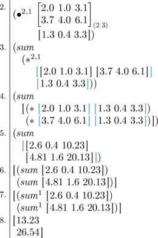

Great.

Here is *linear*, which is similar to *linear*<sup>1</sup><sup>,</sup><sup>1</sup> from frame 197:14, except that it uses *•*<sup>2</sup><sup>,</sup><sup>1</sup> instead of *•*

(**define** *linear* •

(λ (*t*)

(λ (*θ*)

(+ (*•*<sup>2,1</sup> *θ*<sub>0</sub> *t*) *θ*<sub>1</sub>))))

<sup>27</sup>

Okay.

What should the shape of *θ*<sub>1</sub> be?

Let's now assume that

*t*

has the shape

(**list** *n*)

and

*θ*<sub>0</sub>

has the shape

(**list** *m n*)

<sup>28</sup>

As in frame 25, the shape of

(*•*<sup>2</sup><sup>,</sup><sup>1</sup> *θ*<sub>0</sub> *t*)

is

(**list** *m*)

Since *θ*<sub>1</sub> is the bias to be added to the outputs of *•*<sup>2,1</sup>, and because we want each neuron to have its own bias, it must also have the shape

(**list** *m*)

What does this tell us about the shape of

((*linear t*) *θ*)

<sup>29</sup>

Its shape is

(**list** *m*)

which means it is a

tensor<sup>1</sup>

of the same length as the number of neurons in the layer.

Exactly!

We now define the layer function *relu*, which is similar to *relu*<sup>1</sup><sup>,</sup><sup>1</sup> from frame 198:17, except that it uses *linear* instead of *linear*<sup>1</sup><sup>,</sup><sup>1</sup>

(**define** *relu* •

(λ (*t*)

(λ (*θ*)

(*rectify* ((*linear t*) *θ*)))))

<sup>30</sup>

How would we use this with our example from frame 9?

We would invoke it with a

*t*

that has the shape

(**list** 7)

and a

*θ*

made up of

(**list** *w b*)

where

*w*

has the shape

(**list** 4 7)

and

*b*

has the shape

(**list** 4)

What is the shape of the output tensor<sup>1</sup>?

<sup>31</sup>

Since we have *relu* as the layer function, the number of neurons is determined by how our *θ* is shaped.

Since *rectify* does not affect the shape of

(*linear t*)

it has the same shape, which is a tensor<sup>1</sup> of the same length as the number of neurons in the layer.

In this example, it is

(**list** 4)

Absolutely right.

A layer of *m* neurons with an input of length *n* should be provided a *θ* where *θ*<sub>0</sub> has the shape

(**list** *m n*)

and *θ*<sub>1</sub> has the shape

(**list** *m*)

What is the shape of the output tensor of this layer?

<sup>32</sup>

It is the same as the number of neurons in the layer

(**list** *m*)

Very good.

We use this relationship between the shapes of *t*, *θ*<sub>0</sub>, and *θ*<sub>1</sub> of *relu* to design our networks.

<sup>33</sup>

Could we see another example of these shapes?

Sure.

Suppose we have an input tensor<sup>1</sup> of shape

(**list** 4)

and we want to pass it to a layer of 3 neurons so that we get a tensor of shape

(**list** 3)

what should the shape of *θ*<sub>0</sub> be?

<sup>34</sup>

Based on frame 32, *n* is 4, *m* is 3, so the shape of *θ*<sub>0</sub> should be

(**list** 3 4)

And what should the shape of *θ*<sub>1</sub> be?

<sup>35</sup>

It should be the same as

(**list** *m*)

which here is

(**list** 3)

The list of shapes of the tensor<sup>2</sup> and tensor<sup>1</sup> parameters necessary for a layer is known as the *shape list* of the *layer*.

What is the shape list for our example layer above?

<sup>36</sup>

It is

(**list**

(**list** 3 4)

(**list** 3))

And, in general, for a dense layer of *m* neurons and an input length of *n*?

<sup>37</sup>

It is

(**list**

(**list** *m n*)

(**list** *m*))

Perfect.

Let's start, as hinted in frame 3, putting together simple networks using our only known layer function *relu*.

<sup>38</sup>

Will we see more layer functions?

There are more coming up, but for now we restrict ourselves to *relu*.

Here is a simple *network function*

(**define** *1-relu*

(λ (*t*)

(λ (*θ*)

((*relu t*) *θ*))))†

Here we have 1 layer, since there is only one invocation of the layer function *relu*.

†Feel free to skip this framenote.

This *1-relu*'s body in two *η*-reductions simplifies to

*relu*

Thanks, Alonzo Church.

<sup>39</sup>

What is a network function?

A network function assembles layer functions together so that the output of one layer becomes the input to the next layer.

<sup>40</sup>

But that also looks like a target function?

It does.

<sup>41</sup>

If they are so similar, why do we have different names for them?

Their ultimate purposes are different.

Network functions are intended to be target functions for a gradient descent optimization process where a *θ* will be learned.

Layer functions, on the other hand, are used to build network functions.

<sup>42</sup>

So *1-relu* is a 1-layer network function, built using the layer function *relu*.

Can we see network functions with more than one layer?

Here is a skeleton of a 2-layer network function

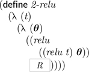

<sup>43</sup>

How is this a 2-layer network function?

The result tensor of the first, inner invocation of *relu* is passed on to the second, outer invocation of *relu*.

<sup>44</sup>

Ah, so the output of the first layer, becomes the input to the second layer.

Aren't we supposed to find *R*?

In a minute.

Let us understand the skeleton a little more. Each of those

*relu*s

requires

two tensor parameters in *θ*

How many tensor parameters should *θ* have?

<sup>45</sup>

Because we have two layers in this network function, and we need two tensor parameters for each layer. The *θ* then must have four tensor parameters.

Correct.

The first two parameters, *θ*<sub>0</sub> and *θ*<sub>1</sub>, are meant for the first layer (i.e., the inner *relu*).

This inner *relu* can simply access them directly from *θ*.†

Does it matter that when the first layer function is invoked with *θ*, it has 4 members in it?

†A slightly more persnickety version of this would be to construct a new list from *θ*<sub>0</sub> and *θ*<sub>1</sub> and pass that to the innermost *relu* instead. Here, however, we use the simpler alternative.

<sup>46</sup>

In frame 27, we see that *relu* contains a *linear* where only *θ*<sub>0</sub> and *θ*<sub>1</sub> are used.

So, it doesn't matter that the *θ* for the first layer has more than *two* members in it because the remaining members are not used by that layer function.

Good.

The last two parameters, *θ*<sub>2</sub> and *θ*<sub>3</sub>, are arguments to the outer *relu*.

Now find *R*.

<sup>47</sup>

*R* must be the *θ* argument of the outer *relu*, which must be a list consisting of *θ*<sub>2</sub> and *θ*<sub>3</sub>. So is this

(**list** *θ*<sub>2</sub> *θ*<sub>3</sub>)?

Correct.

But there's another function that can be used here and is more general.

<sup>48</sup>

What function is that?

It is a function that gives us the rest of the list starting at the *i*th member of a non-empty list *l*, where *i* is positive.

We write it†

*l<sub>i</sub>*<sub>↓</sub>

†Thanks, Kenneth Eugene Iverson (1920–2004).

<sup>49</sup>

An example?

For example

1. 1. (**list** 2 4 8 9 6 3 7)<sub>4↓</sub>
2. 2. (**list** 6 3 7)

<sup>50</sup>

Ah!

This example gives us the rest of the list starting at index 4.

So instead of

(**list** *θ*<sub>2</sub> *θ*<sub>3</sub>)

we can use

*θ*<sub>2↓</sub>

Perfect.

Here's *2-relu*

(**define** *2-relu*

(λ (*t*)

(λ (*θ*)

((*relu*

((*relu t*) *θ*))

*θ*<sub>2↓</sub>))))

We use *θ*<sub>2↓</sub> to get the rest of *θ* starting at index 2. Now let's define a 3-layer network function, *3-relu*.

<sup>51</sup>

Can we use *2-relu* to define *3-relu*?

Yes we can!†

Define a function *3-relu* which is a 3-layer network function, with three *relu*s. And do it using *2-relu*.

†Thanks, Keith Chapman (1959–) for the creation of *Bob the Builder* (1997–).

<sup>52</sup>

How about this?

(**define** *3-relu*

(λ (*t*)

(λ (*θ*)

((*2-relu*

((*relu t*) *θ*))

*θ*<sub>2↓</sub>))))

Very good.

We first invoke *relu* on the input *t*, and let it use up the first two members of *θ*. This is the output of the first layer.

So, *θ* must have two tensor parameters for each of those

*relu*s

Now explain the rest of it.

<sup>53</sup>

We pass the output of the first layer to *2-relu*, which is a 2-layer network function, and provide it with all but the first two members of *θ*.

Can we generalize these functions for any given natural number *k* of layers?

Yes, indeed!

But we'll get there in a couple of steps. Let us begin with a simple recursive function that can do this

(**define** *k-relu*

(λ (*k t* *θ*)

(**cond**

((*zero? k*) *t*)

(**else** (*k-relu* (*sub1 k*)

((*relu t*) *θ*)

*θ*<sub>2↓</sub>)))))

We start with a tensor *t* and run it through *k* invocations of *relu*, at each invocation using up two members of *θ* to produce a final output tensor.

<sup>54</sup>

It is defined so that at least one of the expression's values shrinks. Here *k* shrinks because of (*sub1 k*) and *θ* shrinks because of *θ*<sub>2↓</sub>.

But this isn't quite correct, is it?

It is not!

The problem is that network functions, as in *1-relu*, *2-relu*, and *3-relu* above, must take their arguments *t* and *θ* *one at a time.* So *k-relu* needs nested λ-expressions. And, the **else**-clause would have to include more parentheses.

<sup>55</sup>

Could we do this slowly?

Yes, indeed.

In the dashed version above, there are three arguments. In the next dashed version, we take the first argument and separate it out into a λ of its own

(**define** *k-relu*

(λ (*k*)

(λ (*t* *θ*)

(**cond**

((*zero? k*) *t*)

(**else** ((*k-relu* (*sub1 k*))

((*relu t*) *θ*)

*θ*<sub>2↓</sub>))))))

The only implication of this is that when we invoke *k-relu*, we must first provide the argument for *k*, and then provide the other two

((*relu t*) *θ*)

and

*θ*<sub>2↓</sub>

<sup>56</sup>

In other words, instead of invoking

(*k-relu* (*sub1 k*) ((*relu t*) *θ*) *θ*<sub>2↓</sub>)

we invoke

((*k-relu* (*sub1 k*)) ((*relu t*) *θ*) *θ*<sub>2↓</sub>)

And we can repeat that for

(λ (*t* *θ*) *…*)

as well.

Correct.

Here is the final *k-relu*

(**define** *k-relu* •

(λ (*k*)

(λ (*t*)

(λ (*θ*)

(**cond**

((*zero? k*) *t*)

(**else** (((*k-relu* (*sub1 k*))

((*relu t*) *θ*)

*θ*<sub>2↓</sub>))))))))†

<sup>57</sup>

This definition seems quite complex.

†Each step from frame 54 is known as “Currying.” Thanks, Moses Schönfinkel and Haskell Brooks Curry.

Let's analyze it case-by-case.

When *k* is 0, we have no layers. So the result is the input, *t*.

When *k* is positive, we find the result of the first layer

((*relu t*) *θ*)

invoking *relu* on the input *t*, and then taking that result, and invoking it on *θ*. This uses up the first two members of *θ*.

What happens next?

<sup>58</sup>

The expression (*k-relu* (*sub1 k*)) gives us a neural network consisting of *k* − 1 layers. We invoke this slightly smaller network on the result of the first layer

((*relu t*) *θ*)

and provide it the remaining members of

*θ*

Could we see an example?

Here is an example where *k* is 4, with *t* and *θ* as the remaining arguments

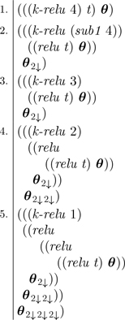

Complete the rest of this same-as chart.

<sup>59</sup>

Here it is

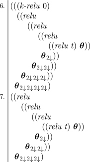

So (*k-relu* 4) gives us 4 invocations of *relu*!

Great.

Now let us look more carefully at a *θ* that goes with a network function created using *k-relu*.

What should *θ* look like for any given *k*?

<sup>60</sup>

In the definition of *k-relu*, we see that every recursive invocation of *k-relu* is accompanied by a *θ*<sub>2↓</sub>, which peels off 2 tensor parameters from *θ*.

Since this happens *k* times for *k* layers, the length of *θ* is *2k*.

In this *θ*, which members are weights and which ones are biases?

<sup>61</sup>

From the definition of *relu*, we know that its *θ*<sub>0</sub> is a weight, and its *θ*<sub>1</sub> is a bias.

This means that in a *θ* for *k* layers, every member at an even index† is a weight tensor, and every member at an odd index is a bias tensor.

†Since lists are indexed starting at 0, we consider 0 to be even.

For the *i*th layer, at which index would we find its weight tensor?

<sup>62</sup>

We would find it at *2i*.

And the bias tensor?

<sup>63</sup>

We would find it at *2i* + 1.

Excellent.

So, if the width of the *i*th layer of the neural network is

*m*

and the length of its input is

*n*

What are the shapes of the tensors at

*2i*

and

*2i* + *1*

<sup>64</sup>

The tensor at 2*i* is the weight tensor and it has the shape

(**list** *m n*)

The tensor at *2i* + *1* is the bias tensor and it has the shape

(**list** *m*)

Great.

It's time for a slightly bigger example. Let's take a 3-layer network where the input is a tensor<sup>1</sup> of shape

(**list** 32)

and the width of

the first dense layer is 64

the second dense layer is 45

the third dense layer is 26

What is the network function for this network?

<sup>65</sup>

It is

(*k-relu* 3)

And, what is the length of

*θ*?

<sup>66</sup>

It is twice the number of layers

6

Correct.

The first layer is 64 neurons wide, with the input of shape

(**list** 32)

So, *θ*<sub>0</sub> must be of shape

(**list** 64 32)

and the shape of *θ*<sub>1</sub> must be

(**list** 64)

What about the second layer?

<sup>67</sup>

The second layer receives its input from the first layer, so its input has the shape

(**list** 64)

The width of this layer is 45 so *θ*<sub>2</sub> must have the shape

(**list** 45 64)

and the shape of *θ*<sub>3</sub> must be

(**list** 45)

The third layer receives its input from the second layer, so its input has the shape

(**list** 45)

<sup>68</sup>

What are *θ*<sub>4</sub> and *θ*<sub>5</sub>?

The width of this layer is

26

so

*θ*<sub>4</sub>

must have the shape

(**list** 26 45)

What about *θ*<sub>5</sub>?

<sup>69</sup>

The shape of

*θ*<sub>5</sub>

comes directly from the width of the layer

(**list** 26)

Correct.

If we combine all these shapes into a single list, we get a *shape list* for the *network*.

What is the shape list for this network?

<sup>70</sup>

It is

(**list**

(**list** 64 32)

(**list** 64)

(**list** 45 64)

(**list** 45)

(**list** 26 45)

(**list** 26))

Excellent.

Together (*k-relu* 3) and this list of shapes fully describe our example neural network.

<sup>71</sup>

How do we go from this description of a neural network to a fully working one?

Step-by-step!

We'll learn the next step in the next chapter.

<sup>72</sup>

Ooh … time for another snack!

## Shapey Toys

•<sup>2,1</sup> 219

*linear* 220

*relu* 221

*l<sub>i</sub>*<sub>↓</sub> (where *l* is nonempty and *i* is positive) 226

*k-relu* 229

**How about a triple berry trifle?**

**With some whipped cream, of course!**

[figure not shown]

†With apologies and thanks to William John Clifton Haley (1925–1981), Bill Haley and His Comets of the 1954 recording for Decca records, Marshall Edward Lytle (1923–2013), Francis Eugene Beecher (1921–2014), William Famous Williamson (1925–1996), John Andrew Grande (1930–2006), William Gussak (1920–1994), Donato Joseph Cedrone (1920–1954), Joseph D’Ambrosio (1934–2021), Producer Milton Gabler (1911–2001), and song writers Max Charles Freedman (1893–1962) and James Edward Myers (1919–2001).

Refreshed?

<sup>1</sup>

The triple berry trifle hit the spot.

Let's go back to our 3-layer network from frame 232:65 where the input is a tensor<sup>1</sup> of shape

(**list** 32)

and the width of

the first dense layer is 64

the second dense layer is 45

the third dense layer is 26

<sup>2</sup>

Yes, where our network function is

(*k-relu* 3)

And what about its shape list?

<sup>3</sup>

Interesting.

It is in frame 233:70

(**list**

(**list** 64 32)

(**list** 64)

(**list** 45 64)

(**list** 45)

(**list** 26 45)

(**list** 26))

Correct.

Here, we have constructed our network function separately from its shape list and we built the shape list by considering only the widths of each layer.

<sup>4</sup>

Is there a problem with doing things that way?

While this separation is sometimes useful, it is more convenient when defining large and complex networks, to

define the layer functions and shapes *together* for each layer

and then

*stack the layers* to combine them into a single network function and a single list of shapes

<sup>5</sup>

Hmm, that sounds a little abstract.

Let's make it real, then.

We begin by introducing *block*s.†

†A *block* is short for *network building block.*

<sup>6</sup>

What is a *block*?

A block associates a layer function with its shape list.

<sup>7</sup>

Could we see an example?

Certainly!

Here is a block for the first layer in our example network

(**define** *layer1*

(*block relu*

(**list**

(**list** 64 32)

(**list** 64))))

Now we invoke the function *block* on two arguments.

Explain these two arguments.

<sup>8</sup>

The first argument is the layer function *relu* and the second argument is the shape list for 64 neurons, and an input tensor<sup>1</sup> of length 32 with shapes in frame 232:67.

Should we define the second layer similarly?

We should.

Show a block for the second layer, *layer2* from that frame, with 45 neurons in it.

<sup>9</sup>

The shapes for the second layer are also in frame 232:67. Here is how we define the block *layer2*

(**define** *layer2*

(*block relu*

(**list**

(**list** 45 64)

(**list** 45))))

And what about the third layer?

<sup>10</sup>

It is defined like this

(**define** *layer3*

(*block relu*

(**list**

(**list** 26 45)

(**list** 26))))

But we still haven't seen what *block* does!

An excellent point.

Here's how we define *block*

(**define** *block* •

(λ (*fn shape-lst*)

(**list** *fn shape-lst*)))

We refer to

*fn*

here as the

*block function*

and the

*shape-lst*

here as the

*block list*

<sup>11</sup>

So it just puts them together in a list?

Simple, isn't it?

Define *block-fn*, which takes a block and returns its function, and *block-ls*, which takes a block and returns its shape list.

<sup>12</sup>

Here they are

(**define** *block-fn* •

(λ (*ba*)

*ba*<sub>0</sub>))

(**define** *block-ls*

(λ (*ba*)

*ba*<sub>1</sub>))

Now let's see the real magic in these blocks.

As frame 233:71 shows, a neural network is fully described by a network function and a shape list.

<sup>13</sup>

Oh, that means a neural network can also be a block!

So stacking blocks together also produces another block.

Let's define the neural network in the example from frame 232:65

(**define** *3-layer-network*

(*stack-blocks*

(**list**

*layer1*

*layer2*

*layer3*)))

<sup>14</sup>

What is *stack-blocks*?

Here, *stack-blocks* is a function that takes a list of blocks and produces a new block whose function

is a combination of the individual block functions

and whose shape list

is made up by joining the individual block lists

<sup>15</sup>

That needs some breaking down, doesn't it?

Let's break that down a little by way of our example, then.

We want our network to first invoke the *relu* from *layer1* on the input tensor<sup>1</sup> of length 32 using the first two parameters of *θ* whose shapes are given by the shape list of *layer1*.

What happens to the output of that invocation?

<sup>16</sup>

The output of the invocation of that *relu* will be a tensor<sup>1</sup> of length 64.

We invoke the *relu* from *layer2* on it, using the next two parameters of *θ* whose shapes are given by the shape list of *layer2*.

Then we do the same thing with the output of this invocation but for *layer3*.

Precisely.

So, in the network, the three *relu*s from each of the layer blocks are *composed* together and this *composite* function consumes 6 parameters from a given *θ*.

What about the shapes of these 6 parameters?

<sup>17</sup>

The shapes of these 6 parameters are given by joining together the shape lists of each of the three layer blocks.

The first two from *layer1*, the third and fourth from *layer2*, and the fifth and sixth from *layer3*.

Can we now define *stack-blocks*?

Yes, but in little pieces.

Here's a function *block-compose*. It expects two block functions *f* and *g* as its first two arguments. Its third argument, *j* is the number of parameters from *θ* that *f* will consume

(**define** *block-compose*

(λ (*f g j*)

(λ (*t*)

(λ (*θ*)

((*g*

((*f t*) *θ*))

*θ**<sub>j</sub>*<sub>↓</sub>)))))

Explain what this function does.

<sup>18</sup>

It returns a block function that expects a tensor *t* followed by *θ*, and then first invokes *f* on *t* and then *θ*.

The result of this invocation is sent as an argument to the invocation of *g*, along with a *θ* from which the first *j* parameters have been removed, because those *j* parameters are intended for *f*.

Could we see an example of how this function works?

Sure.

Let us compose two *relu*s together. We know that a *relu* expects two parameters, so *j* will be 2

1. 1. (*block-compose relu relu* 2)
2. 2. (λ (*t*)
3. (λ (*θ*)
4. ((*relu*
5. ((*relu t*) *θ*))
6. *θ*<sub>2↓</sub>)))

<sup>19</sup>

This is the same function as *2-relu*, isn't it?

It is!

We could also define *2-relu* this way

(**define** *2-relu*

(*block-compose relu relu* 2))

<sup>20</sup>

This doesn't seem like enough to define *stack-blocks*.

No, it isn't.

We must also find a method to join the two block lists.

<sup>21</sup>

There must be a function for that.

There is, and it is called *append*. Here is how it works

1. 1. (*append* (**list** 3 6 1) (**list** 7 2))
2. 2. (**list** 3 6 1 7 2)

<sup>22</sup>

How does it behave on the block lists of *layer1* and *layer2*?

Let us find out

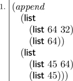

Finish this same-as chart.

<sup>23</sup>

So *append* preserves the shapes, but joins the lists of shapes in the order of the arguments.

Correct.

We can use *block-compose* in frame 18 and *append* in frame 22 to define a function *stack2* that stacks two blocks *ba* and *bb*. Here is its skeleton

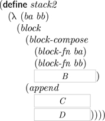

Find *B*, *C* and *D*.

<sup>24</sup>

*B* is the third argument to *block-compose* so it must be the number of parameters consumed by the block function

(*block-fn ba*)

which is

*|*(*block-ls ba*)*|*

*C* and *D* are shape lists that must be appended to get the final shape list for the block. Therefore

*C* is (*block-ls ba*)

and

*D* is (*block-ls bb*)

Great.

Here is *stack2*

(**define** *stack2*

(λ (*ba bb*)

(*block*

(*block-compose*

(*block-fn ba*)

(*block-fn bb*)

|(*block-ls ba*)|)

(*append*

(*block-ls ba*)

(*block-ls bb*)))))

<sup>25</sup>

Are we now ready to define *stack-blocks*?

We are!

The function *stack-blocks* takes one argument *bls*, which is a list of blocks that we must stack

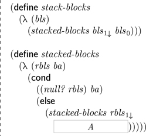

Here, the predicate *null?* checks whether a list has any members. The stacking is done by *stacked-blocks* whose first argument is a list of blocks, and whose second argument is a block that starts off the stacking.

<sup>26</sup>

It seems that these definitions follow the law of simple accumulator passing.

We're invoking *stacked-blocks* with the second argument as the first block in *bls*, and the first argument as the remaining blocks in *bls*.

We must find *A*, mustn't we?

We must!

The function *stacked-blocks* accepts two arguments, the first being a

list of blocks *rbls*

and the second

a block *ba*

onto which the blocks from *rbls* will be stacked.

The second argument *ba* can be thought of as an accumulator that holds a partially-combined block.

Now find *A*.

<sup>27</sup>

Here, if *rbls* is empty, then we don't need to do any further stacking and, we return the partially-combined block *ba*.

Otherwise, we must combine the accumulator block

*ba*

with the first block

*rbls*<sub>0</sub>

and use it as the new value of the accumulator as we traverse down the rest of the blocks using *stacked-blocks*.

So, *A* is

(*stack2 ba rbls*<sub>0</sub>)

Excellent.

Here's the complete definition

(**define** *stack-blocks* •

(λ (*bls*)

(*stacked-blocks bls*<sub>1↓</sub> *bls*<sub>0</sub>)))

(**define** *stacked-blocks*

(λ (*rbls ba*)

(**cond**

((*null? rbls*) *ba*)

(**else**

(*stacked-blocks rbls*<sub>1↓</sub>

(*stack2 ba rbls*<sub>0</sub>))))))

<sup>28</sup>

How about an example of how it works?

Sure.

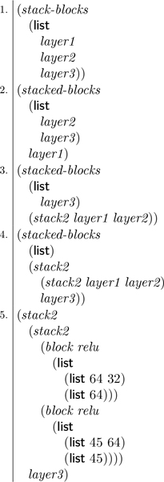

Now finish this same-as chart.

<sup>29</sup>

Here we go

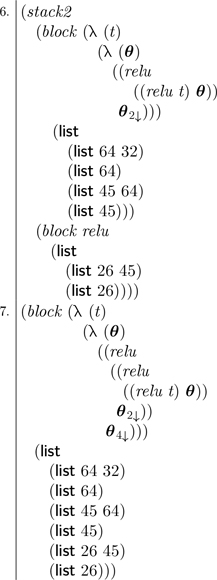

## The Law of Blocks

Blocks can be stacked to form bigger blocks and complete networks.

| Excellent. We can also define functions that produce specific kinds of blocks. Here's a useful one (**define** *dense-block* • (λ (*n m*) (*block relu* (**list** (**list** *m n*) (**list** *m*))))) He… | <sup>30</sup> | It produces a dense layer block with *relu* as the block function and the corresponding dense layer shape list for *m* neurons working on a tensor<sup>1</sup> of length *n*. |
| --- | --- | --- |
| Great. Using *dense-block*, rewrite our definitions of *layer1*, *layer2*, and *layer3*. | <sup>31</sup> | Here they are (**define** *layer1* (*dense-block* 32 64)) (**define** *layer2* (*dense-block* 64 45)) (**define** *layer3* (*dense-block* 45 26)) |
| Once we have a network defined like this, and we have a data set, we can find a well-fitted *θ* for the network function such that the members of *θ* have exactly the shapes dictated by the shape list… | <sup>32</sup> | What's our next dessert? |

## Blocky Toys

*block* 239

*block-fn* 240

*block-ls* 240

*stack-blocks* 245

*dense-block* 247

**How about a stack of crêpes suzette?**

**Flambéed!**

**This space reserved for caramel stains**

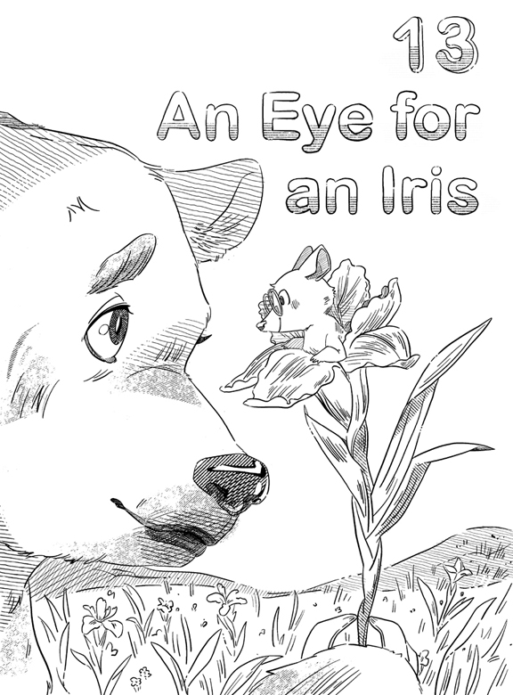

[output not shown]

## The Rule of Layer Initialization

(Initial Version)

The bias tensor<sup>1</sup> of a layer is initialized to contain only 0.0

The weight tensor<sup>2</sup> of a layer is initialized to random scalars with a central value of 0.0 and a variance of 2/*n* where *n* is the length of the input to the layer.

Yes, and we can bake that into a function.

Here is a function *init-**θ* that accepts a single argument *shapes*, which is a shape list corresponding to a *θ*

(**define** *init-**θ*

(λ (*shapes*)

(*map init-shape shapes*)))

Its task is to produce a randomly initialized *θ* based on the shapes found in the shape list.

<sup>55</sup>

It maps the function *init-shape* over each shape in *shapes*.

This means that *init-shape* must generate the tensor we need from its argument shape.

Correct.

When that shape is of the form

(**list** *m*)

we know that it corresponds to a bias tensor. This means we have to construct a tensor with 0.0's in that shape.

<sup>56</sup>

Is there a function for that?

There is!

It is called *zero-tensor* and it takes a *shape* as its argument and produces a tensor with that shape, but every scalar in that tensor is 0.0.

For example

1. 1. (*zero-tensor* (**list** 5))
2. 2. [0.0 0.0 0.0 0.0 0.0]

<sup>57</sup>

Seems like exactly what the doctor ordered.

What if our shape corresponds to a weight tensor?

In the case of dense layers, the shape corresponding to a weight tensor is of the form

(**list** *m n*)

where *m* is the number of neurons in the layer and *n* is the length of the input of the layer.

How should we initialize a tensor with this shape?

<sup>58</sup>

As per our rule, it must be randomly initialized with a central value of 0.0 and a variance as given in frame 53.

Correct.

Here's a skeleton for *init-shape*

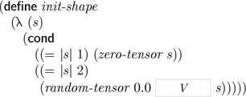

Find *V*.

<sup>59</sup>

*V* is the variance of the weights, which is 2 divided by the length of input. In the case of the shape of weight tensors, this is given by the second member of the shape

*s*<sub>1</sub>

Therefore, *V* is

(÷ 2 *s*<sub>1</sub>)

Here is *init-shape*

(**define** *init-shape*

(λ (*s*)

(**cond**

((= *|s|* 1) (*zero-tensor s*))

((= *|s|* 2)

(*random-tensor* 0.0 (÷ 2 *s*<sub>1</sub>) *s*)))))

<sup>60</sup>

Are we now ready to train our neural network?

Yes, we are!

Let's pick a data set to train it with.

<sup>61</sup>

Are we going to pick Uncle Edgar's data set of 150 plants?

Yes, but we won't use all of them.

We'll save some of those points for testing our network.

<sup>62</sup>

Why haven't we done this for our previous data sets?

Great question.

Our previous data sets have been used to illustrate only the process of gradient descent and how to improve it.

In practice, once a *θ* has been learned, we must test it on points not seen before in order to assess the performance of the network.

<sup>63</sup>

How many points should we set aside from the data set?

We'll reserve 10%, or 15 points, of the data set, with 5 picked randomly from each of the three classes. We'll refer to this as our *test set*.

<sup>64</sup>

Is that enough?

On larger data sets, the general guideline is to use 20% of the data set for testing. Since our data set here is quite small, we limit the test set to 10%.

<sup>65</sup>

Okay.

We'll refer to the *xs* and *ys* for this test set as

(*iris-test-xs*, *iris-test-ys*)

The remaining 135 points form the *training set*. Let's refer to the *xs* and *ys* for this as

(*iris-train-xs*, *iris-train-ys*)

<sup>66</sup>

Those names sound reasonable.

Should we train our network now?

Yes, we should!

What is the target function we need?

<sup>67</sup>

It is the network function of *iris-network*

which is

(*block-fn iris-network*)

Great.

Let us give it a name

(**define** *iris-classifier*

(*block-fn iris-network*))

<sup>68</sup>

Should we also name the shape list?

That's a good idea!

(**define** *iris-**θ**-shapes*

(*block-ls iris-network*))

<sup>69</sup>

Now could we please train the network?

Here's the skeleton for finding *θ* using stochastic gradient descent with *naked-gradient-descent* and *sampling-obj*

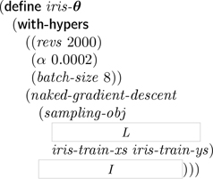

Find *L* and *I*.

<sup>70</sup>

*L* is an expectant function. It is the invocation of *l2-loss* on a target function, which here is *iris-classfier*. So, *L* is

(*l2-loss iris-classifier*)

*I* must be an initial *θ*, initialized with random values but with the shapes given by *iris-**θ**-shapes*. We find it using

(*init-**θ* *iris-**θ**-shapes*)

Good answer.

Here's how we train our network to obtain *iris-**θ*, which is the well-fitted *θ* for our training set

(**define** *iris-**θ*

(**with-hypers**

((*revs* 2000)

(*α* 0.0002)

(*batch-size* 8))

(*naked-gradient-descent*

(*sampling-obj*

(*l2-loss iris-classifier*)

*iris-train-xs iris-train-ys*)

(*init-**θ* *iris-**θ**-shapes*))))

The function *iris-classifier*, together with

*iris-**θ*, form a *model*.

<sup>71</sup>

What is a model?

A model is an approximation of an *idealized* function represented by the data set. This idealized function yields, for every *x* in the *xs* of the data set, the corresponding *y* from *ys*, but also produces a *y* for any given *x*, even if it is not in *xs*.

<sup>72</sup>

Why is this function idealized?

We refer to it as idealized because we assume its existence, but the evidence we have of this is only the data set itself. In other words, we don't have a

(λ (*x*) *. . . some y . . .*)

that defines this function.

For our irises, we define *iris-model*

(**define** *iris-model*

(λ (*t*)

((*iris-classifier t*) *iris-**θ*)))

Explain how this function behaves.

<sup>73</sup>

This function first invokes *iris-classifier* with the input tensor *t* and then *iris-**θ*. Its result is the output tensor produced by *iris-classifier*.

We can generalize *iris-model* into a function *model* that constructs a model out of its two arguments, a target function and a *θ*

(**define** *model* •

(λ (*target* *θ*)

(λ (*t*)

((*target t*) *θ*))))

Explain how this function works.

<sup>74</sup>

It accepts a *target* and a *θ* and results in a function that expects an argument, and invokes *target* on that argument and the given *θ*.

In other words, it produces a model derived from *target* and *θ*.

Excellent.

Now define *iris-model* using *model*.

<sup>75</sup>

Here it is

(**define** *iris-model*

(*model iris-classifier iris-**θ*))

Perfect.

If our model is trained properly, it should produce results as close to the idealized function as possible.

For example, if *iris-model* is given a new set of measurements that are not present in the training set, it still correctly classifies most of the time.

<sup>76</sup>

How do we know that the *θ* in this model is well fitted?

That is an excellent question, but we'll discover the answer to that in the next interlude!

<sup>77</sup>

Oh, and we need a snack, too, don't we?

## Classy Toys

*init-**θ* 262

*zero-tensor* 263

*random-tensor* 264

(*iris-test-xs*, *iris-test-ys*) 265

(*iris-train-xs*, *iris-train-ys*) 265

*iris-classifier* 265

*iris-**θ**-shapes* 265

*iris-**θ* 266

*model* 267

*iris-model* 267

**How about an exquisite mille-feuille?**

**Layers upon layers of deliciousness!**

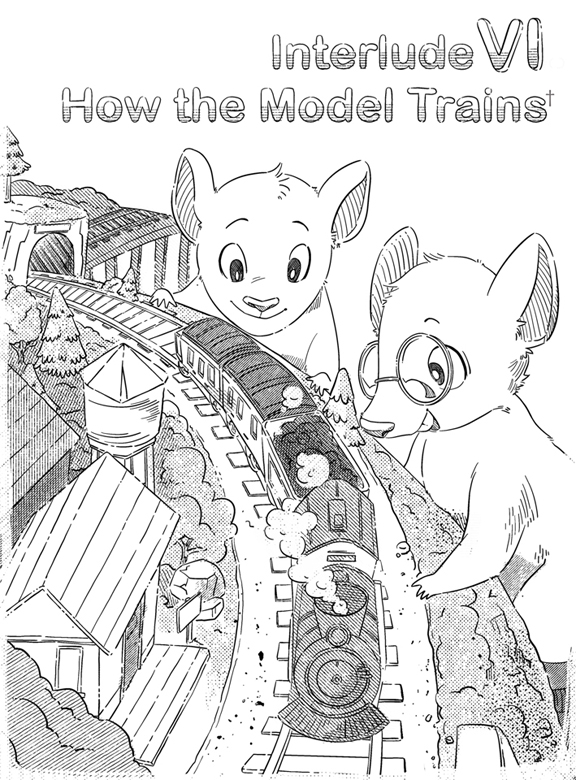

†Thanks, Sir Henry Joseph Wood (1869–1944).

The mille-feuille was wonderful.

<sup>1</sup>

The layers were delightful!

In this interlude, we learn how to determine if a given model is good enough.

<sup>2</sup>

So then we can determine if

*iris-model*

is good enough.

Correct.

So, let's quantify what “good enough” means.

<sup>3</sup>

That would be helpful.

For a given input, classifiers produce a one-hot-like encoding, as in frame 255:23. This output tensor<sup>1</sup> encodes a class that the input belongs to.

<sup>4</sup>

Yes.

The index with the highest degree of belief gives us the class.

To determine if *iris-model* is good enough, we run *iris-model* on the *xs* of a test data set.

In frame 265:66, we have saved a few points in the form of *iris-test-xs* and *iris-test-ys* for testing. Here's where they come into play.

Write an expression for how we can invoke *iris-model* on this test set.

<sup>5</sup>

We can invoke *iris-model* directly on *iris-test-xs*

(*iris-model iris-test-xs*)

Perfect.

Let's name the result of this expression *iris-pred-ys*. Then, we compare the classes represented by *iris-pred-ys* with the known classes represented by *iris-test-ys* from Uncle Edgar's Iris's data set.

We say that the model is accurate for those inputs where the two classes are the same.

<sup>6</sup>

What about when the classes are not the same?

Those are known as *classification errors*.

The ratio of the number of accurate classifications to the total number of test inputs we have is known as the *accuracy* of the model.

<sup>7</sup>

Ah, so we can measure the accuracy of *iris-model* to decide if *iris-**θ* is good enough.

Correct.

<sup>8</sup>

What's a good accuracy score? Is it 1.0 (i.e., the model is accurate on all the test inputs)?

That usually depends upon the problem we're dealing with, but when problems are sufficiently complex, no model is accurate on all inputs. Not even *homo sapiens*.

For this problem, we'll consider 0.9 to be a good enough accuracy score.

<sup>9</sup>

So if 9 out of 10 inputs are correctly classified, we'll consider *iris-**θ* to be good enough.

Yes, that's right.

This way of judging models is quite general, and we can use it for other classifiers as well.

<sup>10</sup>

Aha!

Does that mean we can define functions to measure the accuracy of classifiers in general?

It does.

And we can use those functions to determine if any given model is good enough for the problem we are dealing with.

<sup>11</sup>

Exciting.

Can we start defining these functions?

Absolutely.

Here is a function *argmax*<sup>1</sup> that finds the index in a tensor<sup>1</sup> with the highest degree of belief. It accepts a one-hot-like tensor<sup>1</sup> and determines the index of its highest scalar. For example

(*argmax*<sup>1</sup> [0.1 0.3 0.6])

Write a same-as chart for this expression.

<sup>12</sup>

The highest value in this tensor<sup>1</sup> is 0.6, which is at index 2

1. 1. (*argmax*<sup>1</sup> [0.1 0.3 0.6])
2. 2. 2

How do we define this function?

Here is the start of *argmax*<sup>1</sup>

(**define** *argmax*<sup>1</sup>

(λ (*t*)

<sup>13</sup>

It invokes a helper function *argmaxed* with a simple accumulator passing of arguments.

How is *argmaxed* defined?

Here's a skeleton for *argmaxed*. It takes a tensor<sup>1</sup> *t*, a count-down index *i*, and *a*, which holds the index of the highest element seen in the tensor<sup>1</sup> so far

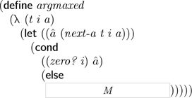

Define *next-a*, which is used to find *â*, the next *a*.

<sup>14</sup>

We must find whether *a* must change to *i* or stay the same. If *i*, has a higher scalar at it in *t* than the one at it in *a*, then we use *i* as the next *a*. Otherwise, we leave *a* alone

(**define** *next-a*

(λ (*t i a*)

(**cond**

((*> t|<sub>i</sub> t|<sub>a</sub>*) *i*)

(**else** *a*))))

Perfect.

Now find *M*.

<sup>15</sup>

When the count-down index is greater than 0, we continue with the next lower index, but now using *â* as the new *a*. So *M* is

(*argmaxed t* (*sub1 i*) *â*)

Excellent.

Here is the completed *argmaxed*

(**define** *argmaxed*

(λ (*t i a*)

(**let** ((*â* (*next-a t i a*)))

(**cond**

((*zero? i*) *â*)

(**else**

(*argmaxed t* (*sub1 i*) *â*))))))

Does this satisfy the law on page 43?

<sup>16</sup>

Indeed it does.

Since *next-a* and *argmax*<sup>1</sup> are not recursive, we can ignore them when determining if *argmaxed* follows the law of simple accumulator passing. The invocation within *argmaxed* is not wrapped, so we need to look at only the formals of *argmaxed*

*t* does not change

*i* changes towards passing a base test

and

*a* accumulates a result

How do we use *argmax*<sup>1</sup>?

When we have two one-hot-like tensors<sup>1</sup>, say *t* and *u*, that represent the same class, what can we say about

(*argmax*<sup>1</sup> *t*)

and

(*argmax*<sup>1</sup> *u*)

<sup>17</sup>

We would expect them to be equal. In other words

(= (*argmax*<sup>1</sup> *t*) (*argmax*<sup>1</sup> *u*))

would be true.

Correct.

We can use this property to begin counting the number of tests that succeed.

Here's a function

*class***=**<sup>1</sup>

that expects

two one-hot-like tensors<sup>1</sup>

and

checks if they represent the same class

(**define** *class***=**<sup>1</sup>

(λ (*t u*)

(**cond**

((= (*argmax*<sup>1</sup> *t*) (*argmax*<sup>1</sup> *u*)) 1.0)

(**else** 0.0))))

Explain what this function does.

<sup>18</sup>

It returns 1.0 if the two tensors<sup>1</sup> represent the same class, and returns 0.0 otherwise.

What is the purpose of such a function?

We'll see shortly.

Let us extend this function

(**define** *class***=**

(*ext2 class***=**<sup>1</sup> 1 1))

<sup>19</sup>

Ah, so we can compare *iris-pred-ys* with *iris-test-ys* with a single invocation of *class***=**

(*class***=** *iris-pred-ys iris-test-ys*)

But this just gives us a tensor<sup>1</sup> of 1.0's and 0.0's.

And that is exactly what we want, because then we can *sum* this tensor<sup>1</sup> to count the number of inputs where *iris-model* is accurate

(*sum*

(*class***=** *iris-pred-ys iris-test-ys*))

How do we find the accuracy from this?

<sup>20</sup>

We must divide it by the number of test inputs

(*class***=** *iris-pred-ys iris-test-ys*))

Excellent.

<sup>21</sup>

We can find the predicted *ys*

(*a-model xs*)

and compare it with *ys*

(*class***=** (*a-model xs*) *ys*)

and then *sum* the result to get *C*

(*sum* (*class***=** (*a-model xs*) *ys*))

Perfect.

Here is the completed *accuracy*

(**define** *accuracy* •

(λ (*a-model xs ys*)

How can we use this function to measure the accuracy of *iris-model*?

<sup>22</sup>

It does happen to be 100% accurate on our small test set of 15 points. This is not so unusual because our data set is simple.

In larger, real-world data sets, accuracies rarely reach such high levels.

<sup>23</sup>

How have we arrived at those hyperparameter scalars that were chosen to train *iris-classifier*?

Those hyperparameter scalars are derived empirically, but there is a more systematic way to determine them.

<sup>24</sup>

That's exciting!

What is the way?

When trying to determine these scalars empirically, we try different combinations for them.

If we know the sequence of scalars that we want to test for each hyperparameter, we can systematically “loop” through each of those scalars for each hyperparameter until we get a satisfactory *θ*.

<sup>25</sup>

Do we use *accuracy* to determine if a *θ* is satisfactory?

Yes.

We can do that if our target function is a classifier. There are other tests for other kinds of target functions.

This way of testing different combinations for the best one is known as

*grid search*

<sup>26</sup>

Do we need something to help us perform a grid search?

We do!

Here's how we do grid searches

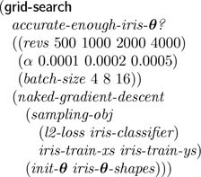

<sup>27</sup>

This is similar to **with-hypers**, but it seems as if there could be more than one scalar for each

hyperparameter

Indeed.

These are the sequences containing *at least* one scalar (and typically more) that **grid-search** tries for each

hyperparameter

<sup>28</sup>

How are these sequences used in **grid-search**?

In this example, **grid-search** first starts with

*revs* is 500

*α* is 0.0001

and

*batch-size* is 4

It then finds a *θ* using the body

(*naked-gradient-descent*

(*sampling-obj*

(*l2-loss iris-classifier*)

*iris-train-xs iris-train-ys*)

(*init-**θ* *iris-**θ**-shapes*))

<sup>29</sup>

This body is similar to what we would use with **with-hypers**.

Correct.

Once it has this *θ*, it tests it with the function *accurate-enough-iris-**θ**?*, which yields #t if this *θ* is accurate enough.

<sup>30</sup>

How is *accurate-enough-iris-**θ**?* defined?

Here we define *accurate-enough-iris-**θ**?* that checks whether the accuracy of a given *θ* when used with *iris-classifier* and the test set

(*iris-test-xs*, *iris-test-ys*)

is high enough

(**define** *accurate-enough-iris-**θ**?*

(λ (*θ*)

(⩾ (*accuracy*

(*model iris-classifier* *θ*)

*iris-test-xs iris-test-ys*)

0.9)))

<sup>31</sup>

This function yields #t if the accuracy is greater than or equal to 0.9.

What happens when a *θ* is not accurate enough?

A great question.

If *accurate-enough-iris-**θ**?* for a *θ* is #t, then **grid-search** yields that *θ*.

If however, *accurate-enough-iris-**θ**?* for a *θ* is #f, then **grid-search** tries another combination.

Then, it keeps the scalars for *revs* and *α* the same as before, but it goes on to the next scalar for *batch-size*, which is 8.

<sup>32</sup>

So the new combination to try

*revs* would be 500

*α* would be 0.0001

and

*batch-size* would be 8

Excellent.

After it reaches the final scalar in the *batch-size* sequence and the *θ* is still not accurate enough, it starts *batch-size* again at the beginning of the sequence, i.e., at 4.

For *α*, however, it continues with the next scalar in the sequence 0.0002, and then tries *all* the scalars of *batch-size* again.

<sup>33</sup>

And when it runs out of *α* and *batch-size* scalars?

It does the same thing: starts with *α* and *batch-size* back at the beginning, but chooses *revs*'s next scalar, and it continues to test whether the *θ* from the body is good enough.

<sup>34</sup>

What happens if we don't find any *θ* that is good enough and we run out of scalars for *revs* as well?

Then **grid-search** itself gives us #f.

<sup>35</sup>

This means that the grid search failed.

Correct.

When that happens, we have to try different sequences of scalars for hyperparameters in the **grid-search**, or possibly try a different target function (e.g. a network with a different number of layers or different layer widths) to use as a classifier. Or, in some situations, we might have to settle for lower accuracy.

<sup>36</sup>

Okay.

Here is the general form of **grid-search**

(**grid-search** *good-enough?*

((*hyperparameter scalar scalar . . .*)

*. . .*)

*body*)

where *body* produces a *θ*, *good-enough?* tests whether that *θ* is good enough, and the *scalar* sequences define all the different combinations that we would like to try for each

*hyperparameter*

<sup>37</sup>

This **grid-search** is a systematic way to determine hyperparameter scalars.

It is!

For now, another snack!

<sup>38</sup>

Something delicious again?

## **Training Toys**

*accuracy* 276

**grid-search** 278

**How about some Belgian waffies?**

**Swimming in maple syrup!**

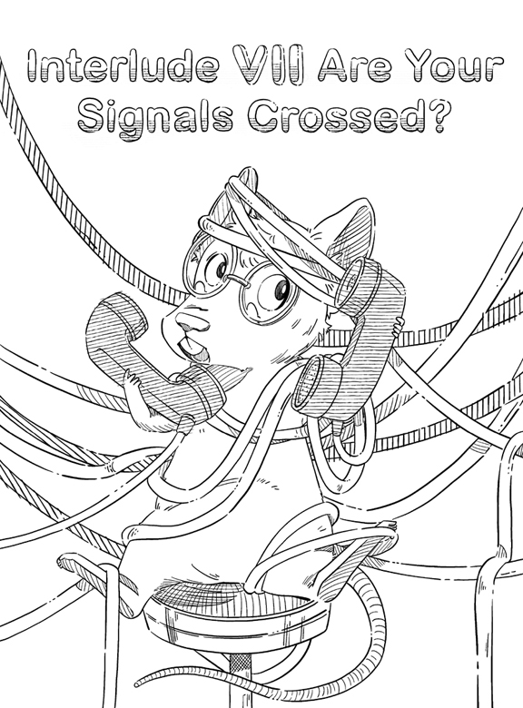

The Belgian waffies† also taste delicious dripping in strawberries and whipped cream.

†Thanks, Maurice Remi Pierre Vermersch (1914–2021).

<sup>1</sup>

A tasty delight!

Let's learn about *signals*.

<sup>2</sup>

What are signals?

They are best learned through an example.

A pair of loquacious learners, Alice and Bob, are close friends and even closer neighbors, but they are forbidden from using their phones at night.

<sup>3</sup>

So what do these loquacious learners do?

They decide to use flashlights† to communicate.

†Thanks, David Misell (1846–1948).

<sup>4</sup>

How do they do that?

They use the International Morse Code.†

†Thanks, Alfred Lewis Vail (1807–1859), thanks, Samuel Finley Breese Morse (1791–1872) and thanks, Friedrich Clemens Gerke (1801–1888).

<sup>5</sup>

You mean the one with dots and dashes?

Exactly!

<sup>6</sup>

<sup>7</sup>

So the letters can be of different lengths?

Yes.

The International Morse Code has many different symbols, but here we restrict our attention to exactly 26 symbols: one for each letter of the alphabet.

<sup>8</sup>

Does that mean we can transmit any message using only dots and dashes for each letter?

Indeed!

That way, Alice and Bob can talk all night using their flashlights.

Alice and Bob decide to build a machine to decode these flashlight messages.

<sup>9</sup>

They have to make one machine for Alice and another one for Bob!

Yes, they do.

The machine uses an *optical sensor* on the window to detect flashes of light from the other learner's flashlight.

<sup>10</sup>

What's an optical sensor?

An optical sensor converts light that falls on it to an electrical output.

The machine then measures the *voltage* of that electrical output.

<sup>11</sup>

What's voltage?

It is a measure of the strength of the electrical output of the optical sensor.

When there is no light falling on the sensor, the voltage is

0.0 volts†

When light from a flashlight falls on the sensor, the voltage is

proportional to the light's strength

For this example, we'll take the sensor's voltage to be between

0.0 (when the flashlight is off)

and

1.0 (when the flashlight is on)

†Thanks, Alessandro Volta (1745–1827).

<sup>12</sup>

How does the optical sensor behave when it is receiving a message?

<sup>13</sup>

How does the output of the optical sensor change over these events?

Initially, when the flashlight is dark, Alice's optical sensor has an output of 0.0 volts. Then, when it is turned on for the dot, the output of the optical sensor rises to 1.0 volts and it stays at 1.0 volts as long as the flashlight is on.

When Bob turns off the flashlight after the dot, the output of the optical sensor drops to 0.0 again for a short while.

Then, when Bob turns on the flashlight again for the dash, the output of the optical sensor rises again to 1.0 volts, and stays there for a longer period, since the dash requires more time, and then drops back to 0.0 volts.

<sup>14</sup>

Is there a visual way to understand these events?

There is.

Let's assume that Bob is able to send one letter in the duration of a second.† Then, we can draw a graph of the voltage on Alice's optical sensor with respect to time over exactly one second.

Here's the graph of the letter a. We refer to it as a *signal graph*

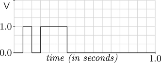

Here V is the abbreviation for *volts*.

†This may be very fast, but we assume Bob is lightning fast.

<sup>15</sup>

Oh, this graph shows how the voltage goes up and goes down for each dot and dash.

That is correct.

<sup>16</sup>

Could we see another example?

Sure.

Here is the letter y

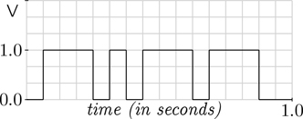

<sup>17</sup>

So this graph shows how the voltage coming out of the optical sensor varies over one second.

Correct.

A *signal* is the variation of a physical quantity (here, its *voltage*) over time.

<sup>18</sup>

So the output of the optical sensor is a signal?

It is an example of what is known as an *analog* signal.†

†This is also known as a *continuous* signal.

<sup>19</sup>

What is Alice going to do with this analog signal?

Since Alice wants to use neural networks to decode these signals, they must be converted to tensors<sup>1</sup>.

Alice uses an *analog-to-digital converter* to convert these electrical signals to tensors<sup>1</sup>.†

†For those familiar with signal processing, we have skipped some details in the description of converting analog signals to tensors since we are primarily concerned with the tensors themselves.

<sup>20</sup>

What do these tensors look like?

Let's first make some simplifying assumptions.

In frame 15, Bob sends flashes at 1 letter per second. We can break up Bob's stream of flashes at 1 second intervals, so that each interval contains one letter.

<sup>21</sup>

So a message containing 10 letters takes 10 seconds?

Correct.

We break up a 1-second period into 16 segments and then assign a scalar to each of those 16 segments, to obtain a tensor<sup>1</sup> corresponding to a single letter in the message.

<sup>22</sup>

What scalars are assigned to each tensor element?

We use the voltage of the signal in the middle of the *i*th segment as the *i*th scalar in the tensor<sup>1</sup>.

<sup>23</sup>

Could we see this on the graph?

Of course.

Here again is the letter y

In this graph, we use an orange circle to mark the scalar picked for each segment

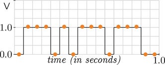

<sup>24</sup>

Each of those *orange* dots represents a scalar element in the tensor<sup>1</sup>.

Here is the whole tensor<sup>1</sup>

[0.0 1.0 1.0 1.0 0.0 1.0 0.0 1.0 1.0 1.0 0.0 1.0 1.0 1.0 0.0 0.0]

Quick! How many 1.0's and 0.0's are here, and where?

<sup>25</sup>

Ooh! That's a ton of 1.0's and 0.0's!

There are, indeed!

†We adopt the convention that an abbreviated tensor never ends in an ellipsis. We see this in the example above which ends in 0.0 instead of an ellipsis.

<sup>26</sup>

Very convenient.

Could we see some more examples?

Sure.

4 off, 4 on, 4 off, and 4 on

Design two similar signals where in the first signal, there are

3 off, 3 on, 3 off, 3 on, 3 off, and 1 on

and in the second signal, there are

5 off, 5 on, 5 off, and 1 on

<sup>27</sup>

and

The digital signals we have so far are tensors<sup>1</sup> where we have a *scalar* at each time segment.†

We refer to these as

signals<sup>1</sup>

†We refer to *time segments* simply as *segments*.

<sup>28</sup>

Oh, so we use the same superscript as we do for tensors.

Correct.

We refer to these as

*1-dimensional* signals<sup>1</sup>

<sup>29</sup>

What does 1-dimensional mean?

It means that the signal consists of values that vary along only one axis, or *dimension*. And that dimension is *time*.

<sup>30</sup>

Okay.

So, when we refer to a signal<sup>1</sup>, it stands for a 1-dimensional signal represented by a tensor<sup>1</sup>.

<sup>31</sup>

Are there signals<sup>2</sup>?

An excellent question!

Yes, a signal<sup>2</sup> is a 1-dimensional signal that contains a tensor<sup>1</sup> in each segment. So, it is actually a tensor<sup>2</sup>.

<sup>32</sup>

Could we see an example of a signal<sup>2</sup>?

Sure.

Do we derive a signal<sup>2</sup> from these two signals<sup>1</sup>?

We “zip” a signal<sup>2</sup> from these two signals *s* and *t* by picking one scalar each from *s* and *t* in lock-step and putting them into a tensor<sup>1</sup>. The resulting signal<sup>2</sup> has 16 segments, each with a 2-element tensor<sup>1</sup>.

<sup>34</sup>

An example, please.

Sure.

The scalar at index 0 of *s* is

0.0

The scalar at index 0 of *t* is

1.0

So the resulting tensor<sup>1</sup> at index 0 of the signal<sup>2</sup> is

[0.0 1.0]

Find the tensor<sup>1</sup> at index 1 of the signal<sup>2</sup>.

<sup>35</sup>

Sounds reasonable.

The scalar at index 1 of *s* is

0.0

The scalar at index 1 of *t* is

0.0

So the resulting tensor<sup>1</sup> at index 1 of the signal<sup>2</sup> is

[0.0 0.0]

Excellent.

<sup>36</sup>

What if we need to zip more than two signals?

A great question.

In general, when we zip *d* signals, each of shape

(**list** *n*)

we get a signal<sup>2</sup> of shape†

(**list** *n d*)

Here, *d* is referred to as the

*depth* of the signal<sup>2</sup>

†This zipping of signals<sup>1</sup>into a signal<sup>2</sup>may be familiar to some as being analogous to *transposing* a matrix.

<sup>37</sup>

The depth of the signal<sup>2</sup> is the number of signals<sup>1</sup> that are used to construct it.

How about an example?

## The Law of Zipped Signals

A signal<sup>2</sup> is formed by zipping signals<sup>1</sup>, and the signal<sup>2</sup> as well as its constituent signals<sup>1</sup> all have the same number of segments.

Sure.

Here is what it looks like

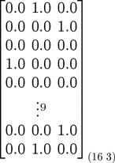

What is the depth of the signal<sup>2</sup> here?

<sup>38</sup>

It is 3, since we have built this signal<sup>2</sup> from 3 signals<sup>1</sup>.

Perfect!

In the signals we have seen so far, the signal begins at 0.0 and changes to 1.0 in the following segment. We refer to the first time we see this change in the signal as its *start*.

Now we relax this assumption to make things more interesting. We'll assume that the start of the signal can occur anywhere in the tensor, as long as the complete signal is present within the 16-segment tensor.

<sup>39</sup>

Could we see an example?

Sure.

Here again, is the signal graph of the letter a, but with a later start

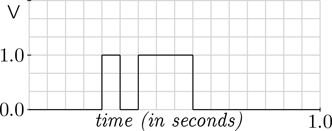

<sup>40</sup>

Excellent.

This shifting the “start” of the signal is known as *translation*.

<sup>41</sup>

So should our locquacious learners build their machines to take translation into account?

Yes, they absolutely should!

Now let's learn about *noise*.

<sup>42</sup>

What is *noise*?

The signal graphs that we have seen so far are *ideal*. In reality, physical signals are never so well-behaved. They have random variations.

<sup>43</sup>

Could we see how these signal graphs look?

As an example, the signal graph for a would more likely resemble this

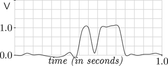

But, because of randomness, the variations would be different each time the signal is sent or received.

<sup>44</sup>

Oh, so the elements in the signal are rarely, if ever, exactly 0.0 or 1.0.

Correct.

For example, our signal<sup>1</sup> for the letter y would probably resemble this

[0.05 1.2 0.96 *−*0.03 1.1 0.09 1.0 0.9

*−*0.02 1.1 1.2 0.2 *−*0.01 *−*0.04 0.1 0.08]

<sup>45</sup>

That signal<sup>1</sup> definitely looks noisy!

How are we to use these signals?

Our loquacious learners’ receivers can decode messages by running these signals through a neural network.

And this neural network must decode these signals even in the presence of noise and translation.

<sup>46</sup>

That's exciting.

Are we going to learn how to write such a neural network?

We are, but that is for later!

<sup>47</sup>

Can't wait to get started!

## Zippy Toys

*zipping signals* 292

**How about a profiterole?**

**With some crunchy choux!**

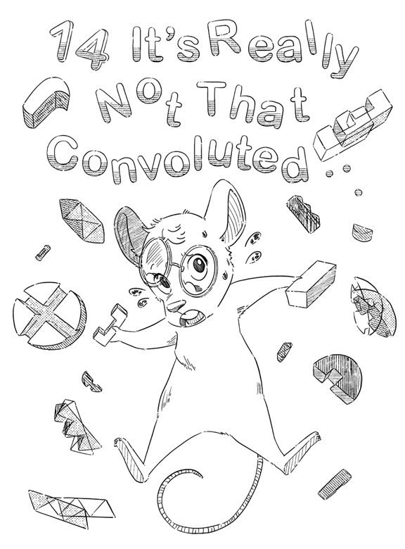

Wasn't the profiterole beyond belief?

<sup>1</sup>

Yes, and it was crunchy!

Here we learn about a new kind of layer.

<sup>2</sup>

Is this layer going to help Alice and Bob decode flashlight messages?

Indeed.

To decode their messages, we need to now learn about *correlation* between two 1-dimensional signals.

<sup>3</sup>

What is correlation?

Correlation is a way to detect the occurrence of a pattern anywhere within a signal.

<sup>4</sup>

Why do we need to detect patterns within a signal?

Detecting patterns within a signal helps us to determine which letter that signal represents.

We detect a pattern by *scanning* the signal from beginning to end and measuring the similarity between a portion of the source signal and the pattern.

<sup>5</sup>

What is scanning?

Scanning is the process of examining every segment of the signal starting at its beginning and going to its end, one segment at a time.

<sup>6</sup>

Could we see an example?

Sure.

<sup>7</sup>

Could we also see its graph?

Here is its graph

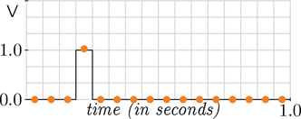

What is its abbreviated signal<sup>1</sup>?

<sup>8</sup>

Here's another signal<sup>1</sup>, but it is much shorter than *s*

[0.0 1.0 0.0]

<sup>9</sup>

This signal<sup>1</sup> seems very similar to the interesting part of *s*, the longer signal<sup>1</sup>.

This signal<sup>1</sup> is a *pattern* that we use to match against the source. We refer to this shorter signal<sup>1</sup> as a filter<sup>1</sup>.†

†Filters are also known as *kernels*.

<sup>10</sup>

This filter has length 3.

All filters are shorter than the source, but are they all of length 3?

They don't have to be. We usually pick them to be a small *odd* number. We use small numbers because small patterns are easier to match. More complex patterns are matched by using many small filters.

<sup>11</sup>

How do we match this filter?

This is where correlation comes in.

<sup>12</sup>

The filter here aligns with the first three elements of the source.

The three elements in the source where the filter and the source overlap determine a tensor<sup>1</sup> for example

[0.0 0.0 0.0]

We refer to this as the

*overlap* at *position* 0

<sup>13</sup>

The overlap determines the elements from the source that overlap with the filter when it is aligned with the source at position 0.

Correct.

Now, let's take the dot product (•) of the filter with this overlap†

1. 1. (*•* [0.0 1.0 0.0] [0.0 0.0 0.0])
2. 2. (*sum*
3. (* [0.0 1.0 0.0] [0.0 0.0 0.0]))
4. 3. (*sum*
5. [0.0 0.0 0.0])
6. 4. 0.0

†As a convention here, the first argument to • is *always* the filter.

<sup>14</sup>

But, what does that mean?

This dot product provides a *scalar* measure of how similar the overlap is to the filter.

<sup>15</sup>

Is it important that this be a scalar?

Yes.

Scalars provide a simple measure of how good a match is.

<sup>16</sup>

What does the measure of 0.0 mean?

It means that the filter is not similar to the overlap at all.

<sup>17</sup>

What should we do now?

What is the overlap now?

<sup>18</sup>

It is

[0.0 0.0 1.0]

Correct.

What should we do next?

<sup>19</sup>

We must find the dot product between the overlap and the filter

1. 1. (*•* [0.0 1.0 0.0] [0.0 0.0 1.0])
2. 2. (*sum*
3. (* [0.0 1.0 0.0] [0.0 0.0 1.0]))
4. 3. (*sum*
5. [0.0 0.0 0.0])
6. 4. 0.0

The dot product is 0.0 again.

Correct.

There is no match at overlap position 0 or overlap position 1.

<sup>20</sup>

So should we slide the filter another position to the right?

Exactly.

What is the dot product now?

<sup>21</sup>

We can find out

1. 1. (*•* [0.0 1.0 0.0] [0.0 1.0 0.0])
2. 2. (*sum*
3. (* [0.0 1.0 0.0] [0.0 1.0 0.0]))
4. 3. (*sum*
5. [0.0 1.0 0.0])
6. 4. 1.0

It is 1.0 this time!

That is correct.

We have a positive (i.e., not a 0.0) value here. This suggests that there is a match between the source and the filter at overlap position 2.

<sup>22</sup>

What about the remaining overlap positions?

All the remaining overlap positions up to 13 give us 0.0.

<sup>23</sup>

Why do we stop at overlap position 13?

That is because beyond position 13, the last element of the filter would extend beyond the last element of the source.

<sup>24</sup>

What do we do next?

<sup>25</sup>

So, correlation determines the dot product of the filter and the overlap at each of the positions from 0 to 13, and builds a signal<sup>1</sup> from these dot products!

Correct.

In general, if our source has *n* segments, and the filter has *m* segments, the correlation has the length

*n − m* + 1

<sup>26</sup>

So that is why the signal in frame 25 has

16 *−* 3 + 1 = 14

elements.

Precisely.

The result of the correlation function has “peaks” where the filter resembles, i.e., correlates with, the source.

<sup>27</sup>

Like the 1.0 at overlap position 2 in frame 21?

Yes.

In order to prevent this loss of information, it would be good to have the source signal and the result signal be the same length.

<sup>28</sup>

What is the second reason?

The second reason is that partial matches between the source and the filter at the boundaries of the source cannot be detected.

<sup>29</sup>

Why can't they be detected?

That is because we started our overlap positions at 0, and we end when the last element of the filter aligns with the last element of the source.

<sup>30</sup>

Could we see an example?

Sure.

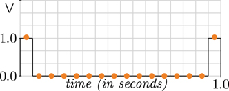

<sup>31</sup>

Oh, then our overlaps miss the partial matches between the source and filter at the beginning of the source and at the end of the source.

Right.

<sup>32</sup>

But there is no element at index −1 in any tensor!

A good observation!

<sup>33</sup>

This allows us to consider an overlap at position *−*1 of the source.

Why both sides?

So that we also consider an overlap position 14 where the filter extends beyond the last element of the source

<sup>34</sup>

By adding these two overlap positions *−*1 and 14 to the 14 other overlap positions we already have, we get a total of 16 overlap positions.

This means the result of correlation is a signal whose length is the same as its source.

<sup>35</sup>

Could we see an example of how padding works?

Sure.

[0.0 1.0 0.0]

What does the overlap look like at position *−*1?

<sup>36</sup>

It should include a padded 0.0 at the beginning so that the middle element of the filter is aligned with the 0th element of the source

[0.0 1.0 0.0]

Let's now take the dot product with the filter and the overlap

1. 1. (*•* [0.0 1.0 0.0] [0.0 1.0 0.0])
2. 2. (*sum*
3. (* [0.0 1.0 0.0] [0.0 1.0 0.0]))
4. 3. (*sum*
5. [0.0 1.0 0.0])
6. 4. 1.0

What would the dot product become at overlap position 14?

<sup>37</sup>

Here it is

1. 1. (*•* [0.0 1.0 0.0] [0.0 1.0 0.0])
2. 2. (*sum*
3. (* [0.0 1.0 0.0] [0.0 1.0 0.0]))
4. 3. (*sum*
5. [0.0 1.0 0.0])
6. 4. 1.0

What about the rest of the overlap positions?

<sup>38</sup>

Why do we refer to it as a signal?

We refer to it as a signal because it now can be a source for more filters, allowing us to *cascade* correlations on a series of different filters.

<sup>39</sup>

What does it mean to cascade correlations?

It means that we perform correlations in a sequence such that the result of one correlation operation is provided as input to the next correlation operation using a different filter.

<sup>40</sup>

Why is this important?

## The Law of Correlation

(Single Filter Version)

The *correlation* of a filter of length *m* with a source signal<sup>1</sup> of length *n*, where *m* is odd (given by 2*p* + 1), is a signal<sup>1</sup> of length *n* obtained by *sliding* the filter from overlap position *−p* to overlap position *n − p −* 1, where *each segment of the result* signal<sup>1</sup> is obtained by taking the *dot product* of the *filter* and the *overlap* in the source at *each overlap position*.

[output not shown]

## The Rule of Filters

Filters are tensor parameters in a *θ*.

Exactly.

We consider filters to be parameters† to a *correlation layer* (i.e., a layer of neurons that uses the correlation operation) in the network, and we learn these filters by training the network on a data set where the *xs* are signals<sup>1</sup>.‡

†These parameters are also known as *filter weights*.

‡For now. Later, we shall see how *xs* is transformed.

<sup>46</sup>

Just as with our loquacious learners’ signals<sup>1</sup>.

But what about the *ys*?

The *ys* are the corresponding letters encoded in a one-hot-like fashion from frame 253:12.

We refer to the two tensors in this data set as

*morse-xs*

and

*morse-ys*

So our neural network classifies each signal<sup>1</sup> in a message into one of 26 classes, one corresponding to each of the 26 letters in our alphabet.

<sup>47</sup>

Does that mean this neural network uses correlation functions to learn the different filters necessary to identify each letter?

Correct.

But we need to evolve our correlation function a little before we can use it in layered neural networks.

<sup>48</sup>

Why do we need to do that?

In a typical neural network classifier, we're simultaneously trying to detect multiple features in a single source.

<sup>49</sup>

Is there a way to do that in a single invocation as we did with *<sup>2,1</sup> from frame 218:22?

Yes, there is.

To do that, we need an analogous operation that correlates against multiple filters in a single function invocation.

<sup>50</sup>

So, how do we handle that?

Let's imagine we have *b* different filters. Each of these filters is a signal<sup>1</sup> and they are all of length *m*.

What can we say about these *b* different filters?

<sup>51</sup>

Together, these *b* filters can be formed into a tensor<sup>2</sup> of shape

(**list** *b m*)

Yes, indeed.

We refer to this tensor<sup>2</sup> as a *filter bank* (or just *bank*).

<sup>52</sup>

How do we correlate a source with a whole bank of filters?

We take each filter in the bank and correlate it with the single source of length *n*, thus giving us *b* different results, where each result is a tensor<sup>1</sup> of the same length as the source.

<sup>53</sup>

Does that mean the output can be packaged into a tensor<sup>2</sup> of shape

(**list** *b n*)?

That is tempting, but then our result would not be a signal<sup>1</sup>, as we expect at the output of a correlation step. Nor would it be a signal<sup>2</sup> because it wouldn't have the same number of segments as the source signal, which is *n*. It would instead have *b* signals<sup>1</sup> in it.

<sup>54</sup>

Is this a problem?

Yes, it is.

It prevents us from cascading the result of this correlation into another correlation layer of the network.

<sup>55</sup>

Oh, that means it gets in the way of detecting more complex features (patterns built from other patterns) as hinted at in frame 41.

So how do we make the output of our correlation on a filter bank look like a signal<sup>2</sup>?

We zip those *b* results, one from each of the *b* filters in the bank, into a signal<sup>2</sup> of

(**list** *n b*)

<sup>56</sup>

How about an example?

<sup>57</sup>

Correlating the source signal with the bank's first filter

and correlating the source signal with the bank's second filter

We now zip, as in frame 292:37, both of those signals into a signal<sup>2</sup>

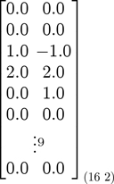

<sup>58</sup>

Okay.

But if we want to cascade correlations using signals<sup>2</sup>, shouldn't correlation work on signals<sup>2</sup> as well?

An excellent question.

Let's see how correlation works on signals<sup>2</sup>.

Say our signals<sup>2</sup> have *n* segments (in our examples, *n* is 16), each being a tensor<sup>1</sup> of length *d*.

<sup>59</sup>

So it is a signal<sup>2</sup> of length *n* and depth *d*.

In order to correlate with signals<sup>2</sup> our filters must themselves be signals<sup>2</sup>, hence now called filters<sup>2</sup>, and they must have the same depth as the source.

What should the depth of our filters be?

<sup>60</sup>

They must also be of depth *d*.

Correct.

Also, like before, we have a bank of *b* filters<sup>2</sup>, where each filter<sup>2</sup> has *m* segments.

The correlations produce a result signal<sup>2</sup> of depth *b*.

<sup>61</sup>

So in this general form, the source, the filter, and the result are all signals<sup>2</sup>.

They are, indeed.

Let us summarize the shapes of our signals. The source has the shape

(**list** *n d*)

and we have a bank of *b* filters of shape

(**list** *b m d*)

where *m* is the width of each filter.

<sup>62</sup>

Could we see an example?

Yes.

Here is the signal<sup>2</sup> from frame 292:36 made by zipping

the signal<sup>1</sup> *s* from frame 291:33

with

the signal<sup>1</sup> *t* also from frame 291:33

Let's name this signal<sup>2</sup> *st*

What are *n* and *d* for *st*?

<sup>63</sup>

For *st*, *n* is 16 and *d* is 2.

Since the depth of our source is 2, the depth of our filters should also be 2.

<sup>64</sup>

Since we have 4 filters<sup>2</sup>, *b* is 4. Each filter<sup>2</sup> has 3 segments, so *m* is 3, and the depth *d* is 2 like before.

Very good.

Let's start with our bank's first filter<sup>2</sup>

[[0.0 0.0] [0.0 1.0] [0.0 0.0]]

at overlap position *−*1.

<sup>65</sup>

If we start at overlap position −1, how do we pad a signal<sup>2</sup>?

<sup>66</sup>

So, instead of using the scalar 0.0 at overlap position −1, we pad the source with a tensor<sup>1</sup> made up of 0.0s.

What is the overlap at position *−*1?

<sup>67</sup>

It is

[[0.0 0.0] [0.0 1.0] [0.0 0.0]]

Correct.

Now we take the dot product of the filter and the overlap

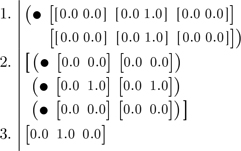

What can we say about the result?

<sup>68</sup>

Our result is a tensor<sup>1</sup> with 3 elements in it, which is the same as the width of our filters.

Oh, but that means the result is not a scalar as we claim it should be in frame 16.

Correct.

How do we turn this tensor<sup>1</sup> into a scalar?

<sup>69</sup>

From the law on page 54, we know that *sum* reduces the rank of a tensor (of rank 1 or higher) by 1.

Excellent.

When correlating signals<sup>2</sup>, we additionally sum the result of the dot product at each overlap position

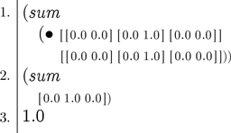

<sup>70</sup>

Now we have a scalar!

The rest of the correlation of this filter is similar. We slide the filter one position down and repeat until we reach overlap position 14, where we pretend the source is padded with

[0.0 0.0]

of shape

<sup>71</sup>

We have to repeat this correlation for all the remaining filters, don't we?

Yes, we must.

Find the final signal<sup>2</sup>.

<sup>72</sup>

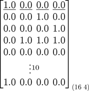

Now we have a way of accepting a signal<sup>2</sup> and producing a signal<sup>2</sup>, and cascading this signal<sup>2</sup> within a layered neural network!

<sup>73</sup>

So is this our final version of the correlation function?

It is!

In a neural network, what we learn are the filters (i.e., the filters are parameters inside *θ*.) The neural network learns to recognize patterns in the input that can then be classified when the filter bank associated with each correlation layer is trained.

In our example, our loquacious learners use correlation to classify each signal as the corresponding letter.

<sup>74</sup>

In our example so far

*n* is 16

*m* is 3

and

*b* is the number of filters in the bank

But, what is *d* ?

A good question.

In a layered neural network, *d* is the depth of the signal produced by the previous layer. We'll see exactly how correlation works within a neural network later.

<sup>75</sup>

Does correlation have a name we can use in our functions?

## The Law of Correlation

(Filter Bank Version)

The *correlation* of a filter bank of shape (**list** *b m d*) with a source signal<sup>2</sup> of shape (**list** *n d*) is a signal<sup>2</sup> of shape (**list** *n b*) resulting from zipping the *b* signals<sup>1</sup> resulting from correlating the *b* filters<sup>2</sup> in the bank with the source.

| Yes! We name it *correlate* It is an extended function similar to •<sup>2,1</sup> from frame 219:24. In the next chapter, we'll learn how to use *correlate*. | <sup>76</sup> | Whew! That was a dizzy ride. Maybe a light snack this time? |
| --- | --- | --- |

## Slidy Toys

(*morse-xs*, *morse-ys*) 309

*correlate* 318

**How about a piece of funnel cake?**

**Funnel cakes *are* convoluted!**

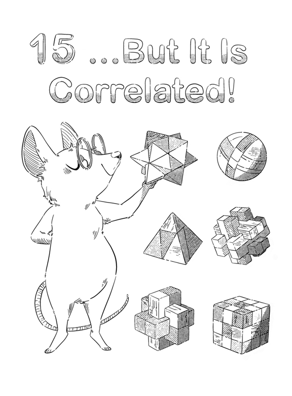

Are we satiated from the funnel cake?

<sup>1</sup>

It was sweet and hearty, and hardly light!

Now that we have correlation, let's use it inside neural networks!

<sup>2</sup>

We have to make a layer function out of it as we did with •<sup>2,1</sup>, don't we?

Yes, we do!

Is correlation a *linear* function like in frame 101:11?

<sup>3</sup>

An interesting question.

It is primarily lots of dot products, so it certainly feels as if it should be linear.

Is it?

It is!

While we won't go into the whole proof here, correlation can be fully described by linear functions. We think of it as an enthusiastic • between tensors.

Here's a function *corr* that combines a tensor *t* with two tensors, *θ*<sub>0</sub> and *θ*<sub>1</sub> from *θ*

(**define** *corr* •

(λ (*t*)

(λ (*θ*)

(+ (*correlate* *θ*<sub>0</sub> *t*) *θ*<sub>1</sub>))))

<sup>4</sup>

So *θ*<sub>0</sub> is a filter bank, since we expect *t* to be a signal<sup>2</sup>.

What is *θ*<sub>1</sub>?

*θ*<sub>1</sub> is known as the bias parameter, which is a tensor<sup>1</sup> that contains one scalar for each filter in the bank.

<sup>5</sup>

Why do we need the bias parameter in *corr*?

Just as in *linear* from frame 199:22, the bias parameter controls the point at which a subsequent invocation of *rectify* makes its decision to result in 0.0.

<sup>6</sup>

Do we combine *corr* and *rectify* similarly to how we combined *linear* and *rectify* to get the function *relu* in frame 198:17?

Yes, exactly!

We are now ready to define a correlation unit *recu*† like *relu* that we use for dense layers.

†This function is also known as *conv*, or *conv1D*, in other neural network systems. Here, however, we use the name *recu* to emphasize its similarity with *relu*.

<sup>7</sup>

What is *recu* short for?

Great question.

It stands for *rectifying correlational unit*

(**define** *recu* •

(λ (*t*)

(λ (*θ*)

(*rectify* ((*corr t*) *θ*)))))

<sup>8</sup>

It is indeed a small variation on *relu*.

Do we use *recu* as we use *relu*?

Almost.

The primary difference lies in the shapes of the parameters in the corresponding *θ*. For *recu*, *θ*<sub>0</sub> must be a filter bank, which is a tensor<sup>3</sup>, whereas *θ*<sub>0</sub> for *relu* is a tensor<sup>2</sup>.

Define the shape list for *recu* where

*b* is the number of filters

*m* is the width of each filter

and

*d* is the depth of the incoming signal

<sup>9</sup>

The shape list of a *recu* consists of one shape for the filter bank and one shape for the bias tensor.

The filter bank has the shape

(**list** *b m d*)

and the bias tensor has the shape

(**list** *b*)

So the shape list would be

(**list**

(**list** *b m d*)

(**list** *b*))

Let's look at the shapes of the inputs and outputs to a *recu*.

If the shape of the input signal<sup>2</sup> *t* is

(**list** *n d*)

where *θ*<sub>0</sub> has the shape

(**list** *b m d*)

and where *θ*<sub>1</sub> has the shape

(**list** *b*)

What is the shape of the output of the *recu* layer?

<sup>10</sup>

Since *rectify* does not change the shape of its argument, the shape of the output is the same as the shape of

((*corr t*) *θ*)

which is the shape of

(+ (*correlate* *θ*<sub>0</sub> *t*) *θ*<sub>1</sub>)

The shape of the result of + is driven by the shape of

(*correlate* *θ*<sub>0</sub> *t*)

which, from the Law of Correlation on page 317 is

(**list** *n b*)

Perfect.

Now define *recu-block*, which defines a single *recu* layer, given *b*, *m*, and *d* as arguments.

<sup>11</sup>

Okay

(**define** *recu-block*

(λ (*b m d*)

(*block recu*

(**list**

(**list** *b m d*)

(**list** *b*)))))

Great.

Networks that use correlation have a special name. They are known as *Convolutional Neural Networks* or CNNs.†

†Thanks, David H. Hubel (1926–2013), Torsten Wiesel (1924–), and Kunihiko Fukushima (1936–).

<sup>12</sup>

Why aren't they named *Correlational* neural networks?

Convolution is a function that is like correlation, except the filters are mirrored (i.e., reversed) before invoking the correlation. CNNs were first characterized using this function.

Since filters are learned during training of the network, it does not matter if we mirror them or not—they are learned in the appropriate direction. So we can avoid the mirroring, leaving just the correlation.

<sup>13</sup>

So, even though the network is named a convolutional neural network, we restrict ourselves to correlations.

The good thing is we can *still* abbreviate them as CNNs.

Is it time to define our CNN?

Let's jump right into it.

Just as we did for *iris-network* in frame 255:21, let us start with the output side of things.

What does our network need to produce as an output?

<sup>14</sup>

It needs to produce a one-hot-like vector of length 26. This means our output layer must produce a tensor<sup>1</sup> of shape

(**list** 26)

Correct.

Let us use that as a design guideline, and propose that our output *recu* layer should have 26 filters, one for each letter we want to detect.

<sup>15</sup>

That sounds like a great idea.

But that doesn't sound quite right. From frame 10, we know that this *recu* layer will produce a signal<sup>2</sup> of shape

(**list** 16 26)

An excellent observation.

We must now convert this signal<sup>2</sup> to a tensor<sup>1</sup>.

<sup>16</sup>

How can we do that?

Let's consider an example.

Suppose that our input signal represents the letter q. Assuming our network is trained well, one of the 26 filters in that *recu* layer will produce a strong output (i.e, a peak) in some segment, while other filters will have a very weak output.

For example, one of the segments will have a tensor<sup>1</sup> of length 26 that might look like this

[0.1 0.0 0.2 0.0 0.1 0.0 0.1 0.0

0.2 0.0 0.1 0.0 0.1 0.0 0.2 0.0

0.8 0.0 0.1 0.0 0.2 0.0 0.1 0.0

0.1 0.0]

<sup>17</sup>

We can see a peak of 0.8 at the position corresponding to q.

What about the other segments?

They will likely have tensors<sup>1</sup> that don't have peaks that stand out.

For example

[0.2 0.1 0.2 0.0 0.1 0.0 0.1 0.0

0.0 0.0 0.1 0.0 0.1 0.1 0.0 0.0

0.0 0.0 0.0 0.1 0.1 0.0 0.0 0.0

0.2 0.0]

<sup>18</sup>

So how do we generate a tensor<sup>1</sup> out of this signal<sup>2</sup>?

We add all these segments together.

Adding them together will produce a tensor<sup>1</sup> where we'll still have a peak at q's position.

<sup>19</sup>

That's an easy solution.

How do we add them?

Let's define *sum*<sup>2</sup>, which adds all the tensors<sup>1</sup> in a tensor<sup>2</sup> together

(**define** *sum*<sup>2</sup>

(λ (*t*)

(**define** *summed*<sup>2</sup>

(λ (*t i a*)

(**cond**

((*zero? i*) (+ *t*|<sub>0</sub> *a*))

(**else**

<sup>20</sup>

This looks exactly like *sum*<sup>1</sup>.

It is, in fact, identical.

Except, that in the expression

*t*|<sub>0</sub>

the result is a tensor<sup>1</sup>, not a scalar.

Because + is an extended operator, *summed*<sup>2</sup> accumulates a tensor<sup>1</sup>, which becomes the result of *sum*<sup>2</sup>.

<sup>21</sup>

So could we just do this?

(**define** *sum*<sup>2</sup> *sum*<sup>1</sup>) •

Awesome, isn't it?

Now we extend this function

(**define** *sum-cols*

(*ext1 sum*<sup>2</sup> 2))

<sup>22</sup>

It is *magnifico*!

We can use this at our output to convert a signal<sup>2</sup> into a tensor<sup>1</sup>.

Almost.

We convert the sum to an *average* first, by dividing it with the number of segments. This is known as *global average pooling*.

<sup>23</sup>

Why do we need to do this?

With *sum-cols* alone, the sum of small partial matches could end up exceeding the actual peak, leading to poor network performance.

<sup>24</sup>

Okay.

Should we extract the number of segments in *t* like this

(*shape t*)<sub>0</sub>?

There is one more factor to consider.

Since *sum-cols* is extended, it may receive a batch of signals<sup>2</sup>, making the rank of *t* greater than 2. So, we must extract the shape of the nested signals<sup>2</sup> like this

(*shape t*)<sub>(- (</sub>*<sub>rank t</sub>*<sub>) 2)</sub>*<sub>↓</sub>*

<sup>25</sup>

Oh, and then its first member is the number of segments in the signal

(*shape t*)<sub>(- (</sub>*<sub>rank t</sub>*<sub>) 2)</sub>*<sub>↓</sub>* <sub>0</sub>

So if *t* has the shape (**list** 8 16 4), we get

1. 1. (**list** 8 16 4)<sub>(- 3 2)</sub>*<sub>↓</sub>* <sub>0</sub>
2. 2. (**list** 8 16 4)<sub>1</sub>*<sub>↓</sub>* <sub>0</sub>
3. 3. (**list** 16 4)<sub>0</sub>
4. 4. 16

Correct, so here is the layer function *signal-avg*

(**define** *signal-avg*

(λ (t)

(λ (*θ*)

(÷ (*sum-cols t*)

(*shape t*)<sub>(- (</sub>*<sub>rank t</sub>*<sub>) 2)↓0</sub>))))

What would the shape list of this layer look like?

<sup>26</sup>

Since it does not use any parameters from *θ*, its shape list is

(**list**)

Excellent.

Now define a block for this layer.

<sup>27</sup>

Here it is.

(**define** *signal-avg-block*

(*block signal-avg*

(**list**)))

Will this be the output layer in our network?

Yes, it will.

Let's start building the other layers, which will all be *recu* layers.

<sup>28</sup>

How many such layers would we need?

Let's go with 8 layers.

<sup>29</sup>

Did we find that empirically as well?

We did, but there's method to our madness.

We expect the earlier layers in the network to detect patterns that are simple. For example, these could be features like rising edges and falling edges of the signal.

<sup>30</sup>

How many layers should we dedicate to that?

Let's give those simple patterns two layers.

The next two layers would match groups of these features into features like dots, dashes and spaces.

<sup>31</sup>

This is what we mean by more complex features in frame 307:41.

Exactly.

The following four layers then detect various groups of those features.

<sup>32</sup>

So will the filters for these layers learn to detect combinations of dots and dashes?

It is hard to say exactly what patterns the filters will learn, since that happens in training.

The idea of a hierarchy of features helps with the initial design, which we then refine through experimentation.

<sup>33</sup>

Okay.

The design of our network in frame 30 is described two layers at a time.

We can conveniently define a block of two layers, and use this block over and over again.

This function defines a block of two *recu* layers, each of which has *b* filters, the width *m*, and the first layer accepts a signal<sup>2</sup> of depth *d*.

<sup>34</sup>

The output of the first recu layer will be a signal of depth *b*. Since the output of the first *recu* layer becomes the input to the next *recu* layer, *B* becomes

*b*

because the third argument to *recu-block* is the depth of its input signal.

Why is this block called *fcn-block*?

Here, *fcn* stands for *fully convolutional network*, because the layers we use are only *recu* with the exception of the output *signal-avg* layer and there are no dense layers.

Here is the completed definition of *fcn-block*

(**define** *fcn-block*

(λ (*b m d*)

(*stack-blocks*

(*recu-block b m d*)

(*recu-block b m b*))))

<sup>35</sup>

So many names *. . .*

Could we please define our network now?

Here it is

(**define** *morse-fcn*

(*stack-blocks*

(**list**

(*fcn-block* 4 3 1)

(*fcn-block* 8 3 4)

(*fcn-block* 16 3 8)

(*fcn-block* 26 3 16)

*signal-avg-block*)))

<sup>36</sup>

How did we arrive at those arguments to the 4 invocations of *fcn-block*?

For our filters, we choose a width of 3, which is sufficient for our network.

The last invocation of *fcn-block* requires 26 filters, as in frame 15.

The first invocation is given 4 filters, to match 4 different features in the input signal. It produces an output signal of depth 4.

<sup>37</sup>

So that is why the next block has the *d* argument as 4.

Correct.

And we can see that in every other call to *fcn-block*, the depth of the signal is equal to the number of filters in the previous block.

We use 8 and 16 filters, respectively, for the other two blocks to allow for a sufficient capacity to match the requisite patterns of features matched by earlier blocks.

<sup>38</sup>

And how are we going to train this network?

We have to start by initializing a *θ* for it.

<sup>39</sup>

We can use *init-**θ*!

We should, but it doesn't yet know how to handle filter banks with shapes of length 3.

<sup>40</sup>

So should we update *init-shape*?

We should. Here's *init-shape* from frame 264:60.

(**define** *init-shape*

(λ (*s*)

(**cond**

((= |*s*| 1) (*zero-tensor s*))

((= |*s*| 2)

(*random-tensor* 0.0 (÷ 2 *s*<sub>1</sub>) *s*)))))

<sup>41</sup>

It does not have a **cond**-clause for shapes of length 3.

Let's add it

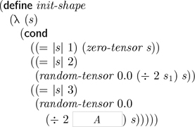

<sup>42</sup>

Aren't we supposed to find *A*?

Soon, but we've yet to determine a rule for initializing filter banks.

<sup>43</sup>

Yes, *n* is the length of the input tensor<sup>1</sup> of that layer.

It is.

The real intent behind it, though, is that *n* is the number of scalars from the input that are multiplied by weights in the layer to produce a single scalar. This is known as

*fan-in*

Dense layers are built using *<sup>2,1</sup> and *sum*, so the fan-in is the length of the input tensor<sup>1</sup>.

<sup>44</sup>

How is it different for *recu* layers?

We use *correlate* for *recu* layers.

In order to produce a single scalar in the output, *correlate* uses only

*m × d*

scalars, because the overlap with any given filter is *m* segments long, and we sum the dot products at each of those segments in the overlap. Each of those dot products uses *d* scalars from the input.

<sup>45</sup>

Ah, so for a filter bank, the fan-in is always

(* *m d*)

Correct.

If *s* describes the shape of a filter bank, how do we find *m* and *d*?

<sup>46</sup>

The shape of a filter bank is

(**list** *b m d*)

so *m* is

*s*<sub>1</sub>

and *d* is

*s*<sub>2</sub>

Perfect.

Now find *A*.

<sup>47</sup>

*A* is the fan-in for a *recu* layer which is

(* *s*<sub>1</sub> *s*<sub>2</sub>)

Excellent.

This is the completed definition of *init-shape*

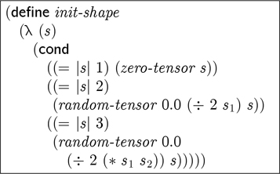

<sup>48</sup>

And now we train the network?

Sometimes it helps the training process if the data set is transformed so that it makes the design of our network easier. We call this *preprocessing*.

<sup>49</sup>

What transformations do we need for our data set?

First, our data set in frame 309:47 introduces *morse-xs* as a signal<sup>1</sup>. As later frames show us, *correlate*, and hence *recu* layers work with signals<sup>2</sup>. So, we must transform *morse-xs* into a signal<sup>2</sup> by wrapping each scalar in an element of *morse-xs* into a tensor<sup>1</sup>.

Show the transformation of this signal<sup>1</sup> into a signal<sup>2</sup>.

<sup>50</sup>

Excellent.

Now for another transformation. The signal data we have varies between a low of approximately 0.0 to a high of approximately 1.0.

Having values very close to 0.0 in the input is always problematic since those values diminish the effect of any weight in a layer.

<sup>51</sup>

How is this problem handled?

We make the signal data swing between a low of approximately −0.5 and a high of approximately 0.5.

That way we avoid having values close to 0.0 in the input.

<sup>52</sup>

Ah, we can achieve that by subtracting 0.5 from the signal!

Correct.

<sup>53</sup>

Don't we need to preprocess the *morse-ys*?

No, that is not necessary, since we only use *morse-ys* to produce the loss.

<sup>54</sup>

Okay.

Now can we train the network?

Let us define a training function to train a network for classifying Morse code signals

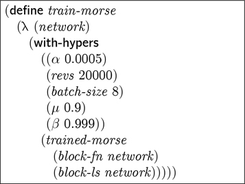

Here we provide the values for the hyperparameters and then use a helper function *trained-morse* to produce a model from a given network.

Now let us define *trained-morse*.

<sup>55</sup>

Okay.

We'll be using stochastic gradient for it, correct?

Yes.

Let us use *adam-gradient-descent*.

To make it stochastic, we'll have to use *sampling-obj* with *l2-loss* as the loss function, and the data set

(*morse-train-xs, morse-train-ys*)

<sup>56</sup>

And we'll have to initialize a *θ* using *init-**θ*.

Here is the definition of *trained-morse*. It accepts a network function *classifier* and a shape list *θ**-shapes* and produces a model using *classifier* and a trained *θ*

(**define** *trained-morse*

(λ (*classifier* *θ**-shapes*)

(*model classifier*

(*adam-gradient-descent*

(*sampling-obj*

(*l2-loss classifier*)

*morse-train-xs*

*morse-train-ys*)

(*init-**θ θ**-shapes*)))))

<sup>57</sup>

How did we arrive at those hyperparameters?

Through a grid search, of course.

<sup>58</sup>

And what is the accuracy of this network?

<sup>59</sup>

A 94% accuracy.

Is that good?

It's pretty good.

But we can do better.

<sup>60</sup>

Interesting.

How?

By using *skip* connections.

<sup>61</sup>

What are skip connections?

Skip connections add the input signal of a block to the output of the block itself.

<sup>62</sup>

What is the purpose of that?

As described in frame 259:43, in very deep networks, as a scalar from the input of a network moves through layers, each layer affects the influence of that scalar on the output.

<sup>63</sup>

Yes, it leads to exploding or vanishing problems that cause difficulty in training networks, which is why we have to carefully initialize our network.

Correct.

Even when the network is carefully initialized, and training proceeds as expected, some weights still become very small and suppress the scalars in the input.

Adding the input back to the output restores the effect of those scalars, allowing those scalars to have more of an effect on the layers that come after.

This improves the training of the network and makes it more effective at what it is supposed to do.

<sup>64</sup>

That sounds great.

How can we add skip connections to *morse-fcn*?

Let's begin by defining a function *skip* which accepts a block function *f,* and adds its input to its output

(**define** *skip*

(λ (*f*)

(λ (*t*)

(λ (*θ*)

(+ ((*f t*) *θ*)

*t*)))))

Explain this function.

<sup>65</sup>

When *skip* is provided a block function *f,* it returns a new block function that adds to the output of *f*

((*f t*) *θ*)

the input to the block function

*t*

Why is this definition dashed?

It is dashed because this addition between the input and the output does not work when the respective depths of the input and output are different. For example, the input has the shape

(**list** *n d*)

and the output has the shape

(**list** *n b*)

and *d* and b are different.

<sup>66</sup>

How do we solve this problem?

We have to convert the input signal from its shape

(**list** *n d*)

to the shape

(**list** *n b*)

<sup>67</sup>

We can do this by using *recu* itself, by using *b* filters, can we not?

The definition of *recu* in frame 8 contains a *rectify*. We don't want to use *recu* directly because this *rectify* might suppress some scalars from the input.

We can, however, use *correlate*, which does not suppress any scalars in the input.

<sup>68</sup>

Okay.

What would its filter bank look like then?

We already know that it needs *b* filters and the depth of the input signal is *d*.

We use the value of 1 for *m*, so that the filters don't merge neighboring values into each other.

What is the shape of this filter bank?

<sup>69</sup>

Ah, using filters of width 1 ensures that the overlap is exactly one segment long, so neighboring segments don't affect the output for that particular segment.

The shape of the filter bank is

(**list** *b* 1 *d*)

Correct.

This filter bank, obviously, adds an additional parameter in the *θ* for every skip connection.

<sup>70</sup>

It's time to see some serious magic!

It's coming. Here is the definition of *skip*, which now accepts a second argument *j*, the number of parameters from *θ* consumed by *f*

(**define** *skip* •

(λ (*f j*)

(λ (*t*)

(λ (*θ*)

(+ ((*f t*) *θ*)

How many parameters does the resulting block function consume from *θ*?

<sup>71</sup>

It consumes

*j* + 1

parameters because *f* consumes *j*, and *correlate* consumes an additional one.

## The Law of Skip Connections

A skip connection for a block with an input of depth *d* and an output of depth *b* requires a bank of shape (**list** *b* 1 *d*) in *θ*.

[output not shown]

## Correlated Toys

*corr* 321

*recu* 322

*skip* 339

*skip-block* 340

**How about some *jalebis* (**जलेबी**)?**

**With a side of clotted cream!**

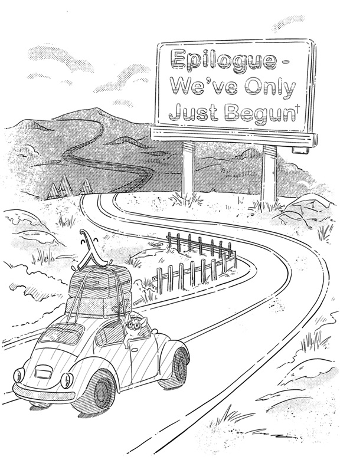

†Thanks, Karen Anne Carpenter (1950–1983), Richard Lynn Carpenter (1946–), and also music arrangers Roger Nichols (1940–) and Paul Williams (1940–).

Any straight path through complex terrain necessarily leaves out the eddies, rivulets and diversions that make the terrain rich and fascinating. Our journey into neural networks has also been such a straight line, and we've deliberately elided many of the features of the terrain that add texture and complexity to the subject. In this epilogue we present a set of destinations that are worth visiting for those interested in exploring further, because in reality, we've only just begun.

## 1 Mathematical foundations

Our presentation of deep learning in previous chapters has used a minimal amount of mathematics necessary, but serious studies of existing machine learning literature requires an understanding of the mathematical foundations of the field. The two most relevant fields are Linear Algebra, and Probability and Statistics. These are often accompanied by a healthy dose of Vector Calculus.

Books like *Deep Learning* [1] provide a very condensed presentation of the necessary mathematics, but assume a certain level of mathematical maturity. To develop this maturity, books such as *Coding the Matrix* [2] (for Linear Algebra) and *Bayesian Statistics the Fun Way* [3] (for Probability Theory) are good for learning these subjects from first principles.

## 2 Data-generating distributions

Data sets are a curious entity. They appear like there's nothing particularly interesting about them. They just contain a large number of points. But in reality, data sets provide us with a sampling of the outputs of a *data-generating process*. For example, in the Morse code example from chapter 14, we describe how the tensors we use are derived from a physical process of pressing a button on a flashlight.

These data-generating processes can be understood in probabilistic terms. We associate them with an ideal *probability distribution*, which maps each point being generated by the process to the probability of its occurrence. We call this the *data generating distribution*.

The process of learning the *θ* of a neural network constructs an internal approximation of this data generating distribution, and applies it to the specific task at hand.

## 3 Tasks

Deep learning is all about doing interesting things. The cognoscenti have given a somewhat boring name to these interesting things. They call them *tasks*.

One interesting objective in many applications is predicting prices of things (like stocks, commodities, real-estate) based on a data set collected from prior transactions. In these applications, the task is to predict a single scalar. These types of tasks are known as *regression* tasks.

Chapter 3 shows an instance of regression based on a linear model, i.e., a linear function and its corresponding *θ*. This kind of model merely implements a mathematical function, but in reality the mathematical function is *modeling* some aspect of the real world, like a price of some asset.

Another set of interesting things to do with neural networks is to identify objects and faces in pictures, identify words in speech or make medical diagnoses from X-ray pictures. These are examples of a task known as *classification*. We encountered classification in chapters 13 and 15.

If we find ourselves in need of language translation services, neural networks can step in and provide such translations. Neural networks have been designed to translate written text from one language to another. Some neural networks additionally can recognize words embedded in pictures and translate them, an application particularly useful in reading signs using the camera on a phone. These kinds of tasks are known as *translation* tasks.

Translation tasks can be applied to pictures too. A particularly fascinating example of such a translation is *style transfer*, where the visual style of an artist is transferred to an input image to produce that same image in the style of that artist.

Another class of applications concerns the *generation* of new points by sampling the data generating distribution the neural network has learned from a data set. For example, we can generate original artistic images or musical compositions that have never been seen before by using specially designed neural networks that have been trained on those types of data sets.

Neural networks are always designed for a specific task that drives the choice of underlying functions and structures. Here we discuss some of the ideas that influence the design space.

## 4 Other loss functions

One of the critical decisions while designing a neural network for a specific task is the choice of the loss function. While *l2-loss* is a broadly applicable loss function [4], other loss functions are also used in different types of applications and tasks. Here we explore some of them.

One popular loss function for classification tasks is *cross-entropy* loss. This loss function has two interesting properties. The first is that each tensor<sup>1</sup> argument must sum up to 1.0, and the second is that each element in the tensors<sup>1</sup> represents probabilities for the corresponding class and thus must lie between 0.0 and 1.0. This loss is defined as follows

(**define** *cross-entropy*

(λ (*target num-classes*)

(λ (*xs ys*)

(λ (*θ*)

(**let** ((*pred-ys* ((*target xs*) *θ*)))

(* *−*1

(÷ (*• ys* (*log pred-ys*))

*num-classes*)))))))

When *ys* is a one-hot vector, *cross-entropy* selects the highest class predicted. The multiplication by −1 is because probabilities are always between 0.0 and 1.0, and their *log* is always negative, giving rise to a negative dot product. Since our convention is to have a positive loss, we multiply it by *−*1.

Cross-entropy loss is usually used in conjunction with a *softmax* decider (we'll see this one soon). In combination, these two functions enable training a network with more accuracy and using fewer revisions.

Here is a loss function that is similar to *l2-loss*, except it uses the absolute value function instead of squaring in order to get rid of negative differences

(**define** *l1-loss*

(λ (*target*)

(λ (*xs ys*)

(λ (*θ*)

(**let** ((*pred-ys* ((*target xs*) *θ*)))

(*sum* (*abs* (*− ys pred-ys*))))))))

This loss function can be used when we don't want outliers in the dataset to disproportionately influence the loss.

## 5 More deciders

The only decider in previous chapters is *rectify*. While it has a number of very useful properties and is extremely simple, *rectify* is a rather recent development. Earlier neural networks relied on nonlinear functions, for example, the *logistic sigmoid*‡ and the hyperbolic *tanh*

(**define** *logistic-sigmoid*

(λ (*x*)

(**let** ((*ex* (*exp x*)))

(÷ *ex* (+ 1 *ex*)))))

(**define** *tanh*

(λ (*x*)

(**let** ((*e2x* (*exp* (* 2 *x*))))

(*÷* (*− e2x* 1) (+ *e2x* 1)))))

These are still applicable in some special cases, but their usage has dropped significantly in favor of *rectify* and its variants.

Variations on *rectify* include a *leaky* rectify [5] that uses a small non-zero slope for inputs that are less than 0.0. We can define it like this

(**define** *leaky-rectify*

(λ (*m*)

(λ (*x*)

(**cond**

((*< x* 0) (* *m x*))

(**else** *x*)))))

The main benefit of a leaky rectify is that it allows for a small amount of negative gradient to pass through when gradients are calculated. This is useful in deep networks as it speeds up training, and avoids some pathological conditions that *rectify* can sometimes cause in large networks. In this definition, the value for *m* must be provided as an argument, but other variations exist where *m* becomes part of the *θ* and thus can be learned [6].

Here is another example of a decider that is somewhat limited in where it can be used, but is used widely in those situations. This is the *softmax* function

(**define** *softmax*

(λ (*x*)

(**let** ((*expd* (*−* (*exp x*) (*max x*))))

(*÷ expd* (*sum expd*)))))

‡Thank you, Pierre-Francois Verhulst (1804–1849).

## 6 Higher-dimensional signals

In order to deal with more complex applications that have to do with images and videos, we need to expand our notion of signals. So far we have only dealt with signals that have samples in one dimension (these were our Morse code signals from frame 290:29). Physical quantities like sounds, seismic vibrations, and variability of temperature often give rise to these types of signals, which are useful in many different applications.

Higher-dimensional signals include images, videos, and others, which arise in a very large number of *visual* applications such as the classification of pictures, transformation of photos, and others. The principles of convolutional neural networks such as correlation are analogous in higher dimensions, except they deal with correlating in more than one dimension instead of one. The function *correlate* is then extended correspondingly to more dimensions.

Higher-dimensional signals give rise to networks that have much larger *θ*s since we're now dealing with a much larger amount of data. It is not uncommon to see *θ*s containing hundreds of millions of scalar parameters in them. Examples of these networks, like AlexNet [7], ResNet [8], and VGG [9], make for extremely interesting architectural explorations.

## 7 Natural language systems

Text-based tasks such as translation and text classification require the processing of natural languages. A neural network designed for natural language processing usually relies on very specific layer structures that allow the network to learn the relationship between words in different parts of a piece of text.

These networks can learn how ideas are threaded through a sequence of sentences and reproduce them as necessary in tasks like translation and summarization. Networks such as GPT-3 [10] carry billions of scalars in their *θ*s and are able to handle very complex tasks.

Sentences in a text processing system are represented by a sequence of tokens. Text processing neural networks work by building models of the probabilities of one word following another one in a sequence. This is then used for tasks like answering questions, machine-generated conversation (known as *chatbots*), text generation, etc. Text processing neural networks can be combined with speech processing neural networks to enable increasingly common applications like voice assistants.

There are two main kinds of architectures used for text processing. There is a *recurrent* neural network architecture that uses an output associated with a prior token for processing a future token. This allows the network to develop information about the context in which a given token appears.

Recurrent networks are rapidly being replaced by a newer form of network based on the idea of *attention* [11]. The difference in attention-based networks is that they work on whole sequences rather than one token at a time. They include a processing block known as a *transformer* that uses attention to provide a mechanism with which the network can learn how each token in the input sequence influences other tokens.

## 8 Generative networks

For applications that require generation, there are two primary types of neural network architectures in use.

The first is known as a *variational autoencoder*. To understand what this does, it is first important to understand what an autoencoder is.

An autoencoder is a neural network that consists of two parts that are trained together, but can be used separately. The two parts are known as the *encoder* and the *decoder*.

The encoder maps every input into a more compact form of the same input. Usually the inputs are tensors consisting of a very large number of scalars. The compact form of the output is usually a tensor<sup>1</sup> consisting of a very small number of scalars. For example, it is possible to have an encoder that can take an image of the letters of an alphabet in a specific font and represent it as a tensor<sup>1</sup> made up of 12 scalars, known as a *code*. By training this encoder on images of different fonts, we can have it produce different codes for each font.

The decoder performs the inverse transformation. It takes the compact form as an input and produces an output that is as close to the original input as possible.

A *variational* autoencoder [12] makes certain that the codes that are produced by an encoder have unique mathematical properties so that they can be treated as samples from a random number generator. Then, by providing new random numbers to the corresponding decoder, new points can be generated that will be similar in characteristics to the original set of inputs the network was trained on.

For example, by providing new random 12-scalar codes to our font decoder, we can produce images of entirely new fonts. The same principles can be used to generate outputs of many different kinds.

The other type of architecture used in generational applications is known as a *generative adversarial network*, or GAN [13]. This type of neural network also consists of two parts.

The first is a generator, which is responsible for converting a random number into an output with the desired characteristics, such as the image of a font. The second is a discriminator, which is responsible for deciding whether the output generated by the generator passes muster. In our example, the discriminator will decide whether or not the image generator is that of a font.

The clever bit about GANs is that their training is designed in a way that both penalizes the discriminator if it is wrong in making a judgment and penalizes the generator if it generates the wrong kind of output.

Training the discriminator and generator together ensures that the generator learns how to produce samples that the discriminator will accept and the discriminator learns to accept only samples that satisfy the application requirements.

## 9 Practical things

One of the most important elements of the design of a neural network is its *capacity*, which can roughly be thought of as the number of scalars in its *θ*. If the network has too few, then it won't learn enough about the training set, a condition known as *underfitting*. If it has too many, then it will learn to be very specific to the training set, a condition known as *overfitting*.

Even if a network has the appropriate capacity, training it with too few *revs* can lead to underfitting, while training it with too many can lead to overfitting.

Either underfitting or overfitting or both might cause the network to not perform optimally. The network will fail to *generalize* to points that lie outside the training set. Selecting networks with the right capacity and choosing the hyperparameters carefully is a very critical part of the network training process.

The concept of the *right* capacity is difficult to define precisely, because design of the network itself influences what “right” means. For example, skip connections can dramatically improve the performance of the network without greatly affecting the number of scalars in *θ*.

Like many things we have seen here, experimentation leads to the development of heuristics and design rules that help build networks of adequate capacity.

A number of practical tricks are necessary in order to train a network properly for given tasks.

First, it always helps to properly track the metrics of a network as it trains. Tracking the training loss, i.e., the value produced by the loss function at each of the *revs*, helps follow how well the network is training.

Second, using a proper validation set to track the relevant performance metric associated with the network (such as accuracy of predictions) helps determine if the training is proceeding correctly.

Third, techniques like *regularization* are used to manage the effectiveness of training. Regularization is the name given to a technique of adding an additional term to the loss function that influences the direction the gradient descent takes. See Good-fellow *et al.* [1] for examples of regularization. This helps train the network without under- or over-training it, which improves the overall performance of the network for its designated task.

Fourth, initialization of weights is a significant part of training. He *et al.* [6] proposed the initialization scheme used in this book. This scheme is useful with rectifier-based networks. Other schemes such as the one proposed by Glorot *et al.* [14] help with other types of networks.

## 10 Onwards, little learners!

This epilogue is a whirlwind tour of the topics and sources for curious readers to pursue. With the understanding of neural networks gained from this book, we hope these topics are less formidable than they would otherwise have been.

*À bientôt*

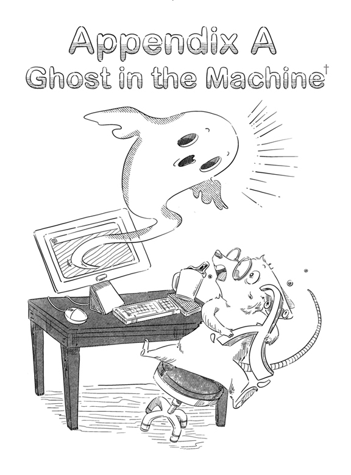

†Thanks, Gilbert Ryle (1900–1976) and *The Police*: Andrew James Summers (1942–), Sting (1951–), and Stewart Armstrong Copeland (1952–).

Starting in chapter 4, almost everything relies on the availability of

the mysterious

∇

This appendix and the next, meant for those who are curious about how it is built, present a full explanation. These definitions provide for complete automatic differentiation that provides a semantic foundation for all the programs demonstrated in the *core* of this book, which is chapters 1 through 15.

This is a superset of what is traditionally known in the history of neural networks as *back propagation.* The back propagation algorithm is an instance of *reverse mode* automatic differentiation, which is what we describe here.

The definitions in the core are written in a consciously functional state of mind, carefully avoiding parts of Scheme that can disrupt this state of mind. The generality of automatic differentiation, however, as well as our desire to keep the definitions easy to understand, requires some of the parts of Scheme we have avoided.

Even though these definitions are written in the *metalanguage,* we have attempted to preserve some of the notation from page xxiii, particularly for list members and vector elements. For readers who are attempting to define these functions as they read along, the notations are as follows.

| Frame | Metalanguage Notation | Transcription as Scheme |
| --- | --- | --- |
| 31 | [*e es . . .* ] | (vector *e es . . .*) |
| 32 | *v*\|*<sub>i</sub>* | (vector-ref *v i*) |
| 51 |  | (vector-length *v*) |
| 51 | *l*<sub>0</sub> | (list-ref *l* 0) or (car *l*) |
| 51 | *l*<sub>1↓</sub> | (drop *l* 1) or (cdr *l*) |
| 72 | (**let****<sup>2</sup>**(⟨*a b*⟩ *E*) *B*) | (let-values (((a b) *E*)) *B*) |
| 75 | ⟨*e1 e2*⟩ | (values e1 e2) |

Symbols like ∇, *σ*, *ρ*, *κ* can be typed in directly as unicode symbols, or they can be spelled out with English letters (e.g. nabla, sigma, rho, kappa).

The rest of this appendix is in the frame format, but the style is not the same. Instead of the familiar question/answer style, it is more a comic-book style. It should be read one frame at a time, from left to right within a frame.

## 1 Prologue

| This is the definition of ∇ (**define** ∇ (λ (*f* *θ*) (**let** ((*wrt* (*map** *dual** *θ*))) (∇*<sub>once</sub>* (*f wrt*) *wrt*)))) | <sup>1</sup> | Flummoxed? Fear not. The goal of this appendix is to fully explain what this definition is about. |
| --- | --- | --- |

## 2 Of gradients and things

[output not shown]

## 3 Primitives, compositions, and chains

[output not shown]

## 4 The representation of scalars

[output not shown]

## 5 Differentiable functions

[output not shown]

## 6 Differentiables

Based on how we construct duals, we should *re-emphasize* here that it is the *dual* itself that carries the chain that has produced it.

<sup>38</sup>

Because of this, we are more concerned with the results that are produced by differentiable functions than we are with the functions themselves.

Duals, however, get embedded within other structures like lists and vectors (for example, in a *θ*). These lists and vectors are, in turn, passed in as arguments to differentiable functions and are produced as results of these functions.

<sup>39</sup>

We refer to scalars, lists, and vectors as

*differentiables*

Differentiables are defined as

scalars

lists of differentiables

or

vectors of differentiables

We can think of differentiables as tree-shaped† structures that have scalars at their leaves. The nodes in this structure are lists and vectors. Further, the scalars at the leaves carry the chains that produced them.

†Actually, directed-acyclic-graph–shaped.

<sup>40</sup>

We often find the need to traverse the structure of differentiables to reach scalars at the leaves.

One useful function for the traversal of a differentiable is *map**. This function produces a new differentiable with the same structure as the argument, but the leaves have other scalars instead.

<sup>41</sup>

The first argument to *map** is a function *f* that accepts a single scalar to produce another scalar. The second argument to *map** is a differentiable *y*.

Then *map** produces a new differentiable where every scalar, say *d*, in *y* is replaced by (*f d*).

We define it like this

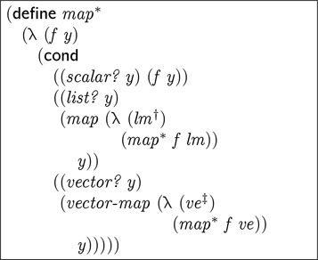

†*l**ist* *m**ember*.

‡*v**ector* *e**lement*.

<sup>42</sup>

This function recursively traverses the structure of *y*. In the base test, where *y* is a scalar, we invoke *f* on *y*, thus producing its new scalar.

For lists (vectors), we traverse the individual members (elements) recursively.<sup>§</sup>

<sup>§</sup>This definition includes the possibility that vectors may contain lists, even though we don't use vectors like that in the core.

This function *dual** converts any scalar to a *truncated dual*. A truncated dual is a dual whose link is always the function *end-of-chain*

(**define** *dual**

(λ (*d*)

(*dual* (*ρ d*)

*end-of-chain*)))

<sup>43</sup>

Here is an example of how to use *map**. If *y* is a differentiable

(*map** *dual** *y*)

produces a differentiable that contains only truncated duals at its leaves. We refer to this kind of differentiable as a

*truncated differentiable*

Now we have some of the machinery to begin understanding ∇

(**define** ∇

(λ (*f* *θ*)

(**let** ((*wrt* (*map** *dual** *θ*)))

(∇*<sub>once</sub>* (*f wrt*) *wrt*))))

<sup>44</sup>

The argument *f* is the function for which the gradient is being sought, and *θ* is the argument to *f* with respect to which we're seeking the gradient.

Since *θ* is a list of tensors and since tensors are either scalars or possibly nested vectors, *θ* is itself a differentiable.

First, we convert *θ* to a truncated differentiable

(*map** *dual** *θ*)

<sup>45</sup>

This abandons any prior links that the scalars in *θ* might contain. The effect of this is that it restricts the gradient to be determined exclusively on what *f* performs, and not on the history of *θ* prior to the invocation of *f* on it.

This truncated differentiable is named *wrt* to remind us that this is the *θ* argument to *f*

*with respect to*

which we are determining gradients.

<sup>46</sup>

It is worth re-emphasizing that *wrt* is identical in structure to *θ*, but each scalar from *θ* in *wrt* now has become a truncated dual.

Thus, it is also worth pointing out that unlike *θ*, *wrt always* contains truncated duals at leaf positions.

We are now ready to invoke *f* on its argument, *wrt*, which is really a dressed-down *θ*. The truncated duals at the leaves of *wrt* become the arguments to chains that get constructed in the invocation of *f* . In other words, all the gradients of the result of this invocation are determined with respect to these truncated duals in *wrt*.

<sup>47</sup>

We invoke the function *f* on *wrt*. Assuming that this invocation terminates, it produces a differentiable and we then determine gradients for this differentiable with respect to *wrt*.

The actual determination of the gradient is carried out by the function ∇*<sub>once</sub>*, which we now describe.